# Deconvolution Porcess

[EcoTyper_Project, Deconvolution Porcess](https://github.com/sogolsahebi/EcoTyper_Project)

Nasim Bondar Sahebi

2024-11-01

## load libraries

```r
library(SummarizedExperiment)
library(MultiAssayExperiment)
library(immunedeconv)
library(ComplexHeatmap)
library(circlize)
library(knitr)
library(kableExtra)
library(dplyr)
library(IOBR)
library(PredictioR)
library(ggplotify)
library(ggplot2)
```

## Goal of the Deconvolution Process

The goal of the EcoTyper and PredictIO projects is to understand the role of immune cells in cancer and how they impact treatment responses. Specifically, the analysis will:

1. **Identify Immune Cells in Tumors**: Using deconvolution methods like **CIBERSORT** and **xCell**, we will profile the immune landscape of tumors, identifying and quantifying various immune cell types in tumor samples. This helps us understand the tumor microenvironment (TME) and its impact on therapy.
2. **Predict Treatment Response**: By comparing responders and non-responders to immunotherapy, we aim to identify immune signatures that predict treatment outcomes and improve patient stratification.
3. **Develop Personalized Therapies**: Insights from immune profiling will guide the design of more targeted, personalized therapies, enhancing cancer treatment effectiveness.

The datasets used in this analysis are immunotherapy datasets curated in the BHK Lab, with sources available on [GitHub](https://github.com/bhklab/ClinSets/tree/main/data). The data has been processed using this [script](https://github.com/sogolsahebi/EcoTyper_Project/blob/main/Scripts/Data_processing.Rmd).

### Overview of Dataset and Clinical Characteristics

#### Inclusion Criteria for Dataset Analysis:

- **Treatments**: Patients treated with `"PD-1/PD-L1"`, `"IO+combo"`, or `"CTLA4"` were included.
- **cell lines**: Only keeping dataset with least 25 patients were considered. (Non-solid tumors were prioritized, while solid tumors like `"Lymph_node"` were excluded.)
- **Sample Types**: Focused on `"PRE"` treatment samples to assess baseline characteristics before therapy.
- **RNA-seq Data**: Only patients with RNA-seq data were included; those with microarray data were excluded.
- **Data Normalization**: RNA-seq data was normalized using `log2(TPM + 0.001)` to ensure comparable expression levels across patients.

#### Display Cohorts used in analysis

Extracts the unique study cohorts from the Immunotherpy dataset and displays them as a table, making it easy to see which cohorts are included in the analysis.

| Dataset | Cancer Type | Sample Size | Clinical Endpoints | Molecular Data | PMID |
| --- | --- | --- | --- | --- | --- |
| Ascierto | Kidney | 11 | Response (R vs NR) | PD-1/PD-L1 |  |
| Auslander | Melanoma | 37 | Response (R vs NR) | CTLA4, PD-1/PD-L1, IO+combo | [30127394](https://pubmed.ncbi.nlm.nih.gov/30127394/) |
| Cloughesy | Brain | 28 | PFS/OS | PD-1/PD-L1 | [30742122](https://pubmed.ncbi.nlm.nih.gov/30742122/) |
| Damrauer | Bladder | 90 | PFS/OS | PD-1/PD-L1 |  |
| Fehrenbacher | Lung | 192 | PFS/OS | PD-1/PD-L1, chemo | [26970723](https://pubmed.ncbi.nlm.nih.gov/26970723/) |
| Gide | Melanoma | 41 | PFS/OS | PD-1/PD-L1 | [30753825](https://pubmed.ncbi.nlm.nih.gov/30753825/) |
| Hugo | Melanoma | 27 | OS | PD-1/PD-L1 | [26997480](https://pubmed.ncbi.nlm.nih.gov/26997480/) |
| Hwang | Lung | 21 | PFS/OS | PD-1/PD-L1 | [31959763](https://pubmed.ncbi.nlm.nih.gov/31959763/) |
| IMmotion150 | Kidney | 326 | Response (R vs NR) | targeted, IO+targeted, PD-1/PD-L1 |  |
| Jerby_Arnon | Melanoma | 112 | PFS | PD-1/PD-L1 | [30388455](https://pubmed.ncbi.nlm.nih.gov/30388455/) |
| Jung | Lung | 60 | PFS | PD-1/PD-L1 | [31537801](https://pubmed.ncbi.nlm.nih.gov/31537801/) |
| Kim | Gastric | 45 | Response (R vs NR) | PD-1/PD-L1 | [30013197](https://pubmed.ncbi.nlm.nih.gov/30013197/) |
| Limagne1 | Lung | 70 | NA | anti-PD-1 | [35051357](https://pubmed.ncbi.nlm.nih.gov/35051357/) |
| Limagne2 | Lung | 26 | NA | anti-PD-1/anti-PD-L1 | [35051357](https://pubmed.ncbi.nlm.nih.gov/35051357/) |
| Liu | Melanoma | 144 | PFS/OS | Combo, PD-1/PD-L1 | [31792460](https://pubmed.ncbi.nlm.nih.gov/31792460/) |
| Mariathasan | Lymph_node, Bladder, Kidney, Ureteral, Lung, Unknown, Liver | 348 | OS | PD-1/PD-L1 | [29443960](https://pubmed.ncbi.nlm.nih.gov/29443960/) |
| Miao1 | Kidney | 52 | PFS/OS | PD-1/PD-L1 | [29301960](https://pubmed.ncbi.nlm.nih.gov/29301960/) |
| Nathanson | Melanoma | 64 | OS | CTLA4 | [27956380](https://pubmed.ncbi.nlm.nih.gov/27956380/) |
| Padron | Pancreas | 45 | PFS/OS | PD-1/PD-L1 | [35662283](https://pubmed.ncbi.nlm.nih.gov/35662283/) |
| Powles | Bladder | 148 | Response (R vs NR) | PD-1/PD-L1 |  |
| Prat | HNC, Lung, Melanoma | 65 | PFS | PD-1/PD-L1 |  |
| Puch | Melanoma | 55 | Response (R vs NR) | PD-1/PD-L1 | [33542239](https://pubmed.ncbi.nlm.nih.gov/33542239/) |
| Ravi | Lung | 148 | PFS/OS | PD-1/PD-L1, IO+chemo, IO+combo | [37024582](https://pubmed.ncbi.nlm.nih.gov/37024582/) |
| Riaz | Melanoma | 72 | OS | Combo, PD-1/PD-L1 | [29033130](https://pubmed.ncbi.nlm.nih.gov/29033130/) |
| Rittmeyer | Lung | 699 | PFS/OS | PD-1/PD-L1, chemo | [27979383](https://pubmed.ncbi.nlm.nih.gov/27979383/) |
| Roh | Melanoma | 25 | OS | CTLA4 | [28251903](https://pubmed.ncbi.nlm.nih.gov/28251903/) |
| Shiuan | Kidney | 15 | Response (R vs NR) | PD-1/PD-L1 | [33806963](https://pubmed.ncbi.nlm.nih.gov/33806963/) |
| Snyder | Ureteral | 25 | PFS/OS | PD-1/PD-L1 | [28552987](https://pubmed.ncbi.nlm.nih.gov/28552987/) |
| Van_Allen | Melanoma | 42 | PFS/OS | CTLA4 | [26359337](https://pubmed.ncbi.nlm.nih.gov/26359337/) |
| VanDenEnde | Esophageal | 35 | Response (R vs NR) | PD-1/PD-L1 | [33504550](https://pubmed.ncbi.nlm.nih.gov/33504550/) |

```r
# Display all unique cohorts used in the analysis
kable(unique(combined_clin$study), caption = "All Cohorts that we are using stratify by cancertype_treatment", col.names = "Cohorts") %>%
  kable_styling(bootstrap_options = c("striped", "hover", "condensed"), full_width = F) %>%
  scroll_box(height = "400px")
```

All Cohorts that we are using stratify by cancertype_treatment

| Cohorts |
| --- |
| ICB_Auslander__Melanoma__PD-(L)1 |
| ICB_Cloughesy__Brain__PD-(L)1 |
| ICB_Damrauer__Bladder__PD-(L)1 |
| ICB_Fehrenbacher__Lung__PD-(L)1 |
| ICB_Gide__Melanoma__PD-(L)1 |
| ICB_Hugo__Melanoma__PD-(L)1 |
| ICB_IMmotion150__Kidney__PD-(L)1 |
| ICB_Jerby_Arnon__Melanoma__PD-(L)1 |
| ICB_Jung__Lung__PD-(L)1 |
| ICB_Kim__Gastric__PD-(L)1 |
| ICB_Limagne1__Lung__PD-(L)1 |
| ICB_Limagne2__Lung__PD-(L)1 |
| ICB_Liu__Melanoma__IO+combo |
| ICB_Liu__Melanoma__PD-(L)1 |
| ICB_Mariathasan__Bladder__PD-(L)1 |
| ICB_Mariathasan__Kidney__PD-(L)1 |
| ICB_Mariathasan__Ureteral__PD-(L)1 |
| ICB_Miao1__Kidney__PD-(L)1 |
| ICB_Padron__Pancreas__PD-(L)1 |
| ICB_Powles__Bladder__PD-(L)1 |
| ICB_Prat__Lung__PD-(L)1 |
| ICB_Prat__Melanoma__PD-(L)1 |
| ICB_Puch__Melanoma__PD-(L)1 |
| ICB_Ravi__Lung__PD-(L)1 |
| ICB_Rittmeyer__Lung__PD-(L)1 |
| ICB_Snyder__Ureteral__PD-(L)1 |
| ICB_Van_Allen__Melanoma__CTLA4 |
| ICB_VanDenEnde__Esophageal__PD-(L)1 |

```r
# summary_dataset[summary_dataset$Dataset %in% studies, ]
#
# # Display all unique cohorts used in the analysis
# kable(summary_dataset[summary_dataset$Dataset %in% studies, ], caption = "All original Cohorts that we are using ") %>%
#   kable_styling(bootstrap_options = c("striped", "hover", "condensed"), full_width = F) %>%
#   scroll_box(height = "400px")
```

#### Display Summary and clinical data

loads and displays two tables: a summary of all data after exclusions and detailed clinical characteristics of the immuno-oncology datasets, using `kable` for a clean, readable format with scrollable boxes.

```r
# Load and display Summary and Clinical datasets.
kable(read.csv(file.path(Base_dir, "outputs/Dataprocessing_outputs/", "Summary_of_Data_After_Exclusion.csv")),
      caption = "Summary of All Data and Data with Sex") %>%
  kable_styling(bootstrap_options = c("striped", "hover", "condensed"), full_width = F) %>%
  scroll_box(height = "400px")
```

Summary of All Data and Data with Sex

| Characteristic | All_Data | Sex_Data |
| --- | --- | --- |
| N° studies | 28 | 30 |
| N° patients | 2021 | 1645 |
| Age year |  |  |
| Median (IQR) | 64 (19-90) | 64 (19-90) |
| NA (%) | 1446 (71.5%) | 416 ( 25.3 %) |
| Sex |  |  |
| Female (%) | 522 ( 25.8 %) | 570 ( 34.7 %) |
| Male (%) | 979 ( 48.4 %) | 1075 ( 65.3 %) |
| NA (%) | 1446 (71.5%) | 416 ( 25.3 %) |
| Cancer Type |  |  |
| Melanoma (%) | 450 (22.3%) | 401 (24.4%) |
| Brain (%) | 28 (1.4%) | 45 (2.7%) |
| Bladder (%) | 433 (21.4%) | 285 (17.3%) |
| Lung (%) | 727 (36%) | 678 (41.2%) |
| Kidney (%) | 207 (10.2%) | 111 (6.7%) |
| Gastric (%) | 45 (2.2%) | NA |
| Ureteral (%) | 51 (2.5%) | 51 (3.1%) |
| Pancreas (%) | 45 (2.2%) | 45 (2.7%) |
| Esophageal (%) | 35 (1.7%) | NA |
| Treatment |  |  |
| PD-1/PD-L1 (%) | 1932 (95.6%) | 1500 (91.2%) |
| IO+combo (%) | 47 (2.3%) | 63 (3.8%) |
| CTLA4 (%) | 42 (2.1%) | 82 (5%) |
| Response |  |  |
| No-response (%) | 1090 ( 53.9 %) | 918 ( 55.8 %) |
| Response (%) | 484 ( 23.9 %) | 424 ( 25.8 %) |
| NA (%) | 1446 (71.5%) | 416 ( 25.3 %) |
| PFS |  |  |
| No-progression (%) | 243 ( 12 %) | 237 ( 14.4 %) |
| Progressed (%) | 1026 ( 50.8 %) | 992 ( 60.3 %) |
| NA (%) | 1446 (71.5%) | 416 ( 25.3 %) |
| Median PFS | 2.9 | 3 |
| IQR PFS | 7 | 8.1 |
| OS |  |  |
| Alive (%) | 454 ( 22.5 %) | 511 ( 31.1 %) |
| Dead (%) | 850 ( 42.1 %) | 921 ( 56 %) |
| NA (%) | 1446 (71.5%) | 416 ( 25.3 %) |
| Median OS | 10.3 | 10.6 |
| IQR OS | 16.3 | 16.1 |

```r
kable(read.csv(file.path(Base_dir, "outputs/Dataprocessing_outputs/" , "Detailed_clinical_characteristics_of_the_IO_datasets.csv")),
      caption = "Detailed Clinical Characteristics of the IO Datasets") %>%
  kable_styling(bootstrap_options = c("striped", "hover", "condensed"), full_width = F) %>%
  scroll_box(height = "400px")
```

Detailed Clinical Characteristics of the IO Datasets

| Study | N | Expression | Age_Median | Age_IQR | Age_NA | Female | Male | Sex_NA | Cancer_Type | Treatment_Type | No_Response | Response | No_Progression | Progressed | PFS_Median | PFS_IQR | Alive | Dead | OS_Median | OS_IQR |
| --- | --- | --- | --- | --- | --- | --- | --- | --- | --- | --- | --- | --- | --- | --- | --- | --- | --- | --- | --- | --- |
| ICB_Auslander__Melanoma__PD-(L)1 | 27 | TPM | 72.0 | 28.5 | 0 | 0 | 0 | 27 | Melanoma | PD-1/PD-L1 | 26 | 1 | 0 | 0 | NA | NA | 0 | 0 | NA | NA |
| ICB_Cloughesy__Brain__PD-(L)1 | 28 | TPM | 63.2 | 11.2 | 0 | 17 | 11 | 0 | Brain | PD-1/PD-L1 | 21 | 1 | 1 | 27 | 2.6 | 3.4 | 8 | 20 | 9.1 | 7.4 |
| ICB_Damrauer__Bladder__PD-(L)1 | 90 | TPM | 70.0 | 14.0 | 0 | 34 | 56 | 0 | Bladder | PD-1/PD-L1 | 69 | 17 | 10 | 79 | 2.1 | 3.6 | 33 | 57 | 5.9 | 7.9 |
| ICB_Fehrenbacher__Lung__PD-(L)1 | 95 | TPM | NA | NA | 95 | 27 | 68 | 0 | Lung | PD-1/PD-L1 | 56 | 14 | 5 | 90 | 2.8 | 7.1 | 16 | 79 | 11.1 | 20.1 |
| ICB_Gide__Melanoma__PD-(L)1 | 41 | NA | 66.0 | 21.0 | 0 | 15 | 26 | 0 | Melanoma | PD-1/PD-L1 | 19 | 19 | 12 | 29 | 9.0 | 27.0 | 17 | 24 | 20.2 | 30.5 |
| ICB_Hugo__Melanoma__PD-(L)1 | 27 | NA | 61.0 | 14.5 | 0 | 8 | 19 | 0 | Melanoma | PD-1/PD-L1 | 13 | 14 | 0 | 0 | NA | NA | 15 | 12 | 14.4 | 18.2 |
| ICB_IMmotion150__Kidney__PD-(L)1 | 107 | TPM | NA | NA | 107 | 0 | 0 | 107 | Kidney | PD-1/PD-L1 | 32 | 22 | 0 | 0 | NA | NA | 0 | 0 | NA | NA |
| ICB_Jerby_Arnon__Melanoma__PD-(L)1 | 112 | NA | NA | NA | 112 | 49 | 56 | 7 | Melanoma | PD-1/PD-L1 | 53 | 43 | 33 | 72 | 3.9 | 10.4 | 0 | 0 | NA | NA |
| ICB_Jung__Lung__PD-(L)1 | 27 | NA | 62.0 | 10.0 | 0 | 5 | 22 | 0 | Lung | PD-1/PD-L1 | 19 | 8 | 6 | 21 | 2.0 | 5.1 | 0 | 0 | NA | NA |
| ICB_Kim__Gastric__PD-(L)1 | 45 | NA | NA | NA | 45 | 0 | 0 | 45 | Gastric | PD-1/PD-L1 | 18 | 13 | 0 | 0 | NA | NA | 0 | 0 | NA | NA |
| ICB_Limagne1__Lung__PD-(L)1 | 70 | NA | NA | NA | 70 | 0 | 0 | 70 | Lung | PD-1/PD-L1 | 52 | 17 | 18 | 52 | 2.7 | 3.8 | 0 | 0 | NA | NA |
| ICB_Limagne2__Lung__PD-(L)1 | 26 | NA | NA | NA | 26 | 0 | 0 | 26 | Lung | PD-1/PD-L1 | 16 | 6 | 6 | 20 | 3.1 | 10.4 | 0 | 0 | NA | NA |
| ICB_Liu__Melanoma__IO+combo | 47 | NA | NA | NA | 47 | 20 | 27 | 0 | Melanoma | IO+combo | 26 | 17 | 10 | 37 | 3.4 | 24.2 | 16 | 31 | 14.0 | 25.0 |
| ICB_Liu__Melanoma__PD-(L)1 | 74 | NA | NA | NA | 74 | 30 | 44 | 0 | Melanoma | PD-1/PD-L1 | 34 | 35 | 25 | 49 | 6.4 | 17.9 | 43 | 31 | 19.0 | 17.6 |
| ICB_Mariathasan__Bladder__PD-(L)1 | 195 | NA | NA | NA | 195 | 42 | 153 | 0 | Bladder | PD-1/PD-L1 | 91 | 42 | 0 | 0 | NA | NA | 67 | 128 | 8.9 | 15.9 |
| ICB_Mariathasan__Kidney__PD-(L)1 | 67 | NA | NA | NA | 67 | 10 | 57 | 0 | Kidney | PD-1/PD-L1 | 37 | 9 | 0 | 0 | NA | NA | 20 | 47 | 7.0 | 11.3 |
| ICB_Mariathasan__Ureteral__PD-(L)1 | 26 | NA | NA | NA | 26 | 10 | 16 | 0 | Ureteral | PD-1/PD-L1 | 13 | 5 | 0 | 0 | NA | NA | 8 | 18 | 10.3 | 15.4 |
| ICB_Miao1__Kidney__PD-(L)1 | 33 | NA | 64.0 | 8.0 | 0 | 9 | 24 | 0 | Kidney | PD-1/PD-L1 | 18 | 10 | 25 | 8 | 2.9 | 11.7 | 10 | 23 | 12.4 | 14.2 |
| ICB_Padron__Pancreas__PD-(L)1 | 45 | NA | 62.0 | 12.0 | 0 | 19 | 26 | 0 | Pancreas | PD-1/PD-L1 | 20 | 3 | 6 | 39 | 5.8 | 6.2 | 11 | 34 | 9.7 | 11.3 |
| ICB_Powles__Bladder__PD-(L)1 | 148 | TPM | NA | NA | 148 | 0 | 0 | 148 | Bladder | PD-1/PD-L1 | 46 | 27 | 0 | 0 | NA | NA | 0 | 0 | NA | NA |
| ICB_Prat__Lung__PD-(L)1 | 35 | log2gNor | 59.0 | 19.0 | 0 | 8 | 27 | 0 | Lung | PD-1/PD-L1 | 18 | 10 | 10 | 25 | 3.2 | 4.7 | 0 | 0 | NA | NA |
| ICB_Prat__Melanoma__PD-(L)1 | 25 | log2gNor | 59.0 | 21.0 | 0 | 7 | 18 | 0 | Melanoma | PD-1/PD-L1 | 15 | 10 | 7 | 18 | 3.2 | 4.8 | 0 | 0 | NA | NA |
| ICB_Puch__Melanoma__PD-(L)1 | 55 | NA | NA | NA | 55 | 0 | 0 | 55 | Melanoma | PD-1/PD-L1 | 35 | 14 | 0 | 0 | NA | NA | 0 | 0 | NA | NA |
| ICB_Ravi__Lung__PD-(L)1 | 130 | TPM | 64.0 | 15.0 | 1 | 70 | 60 | 0 | Lung | PD-1/PD-L1 | 62 | 45 | 27 | 91 | 4.1 | 7.9 | 62 | 63 | 10.7 | 14.6 |
| ICB_Rittmeyer__Lung__PD-(L)1 | 344 | TPM | NA | NA | 344 | 125 | 219 | 0 | Lung | PD-1/PD-L1 | 221 | 53 | 30 | 314 | 2.5 | 5.5 | 107 | 237 | 10.8 | 16.9 |
| ICB_Snyder__Ureteral__PD-(L)1 | 25 | NA | 68.0 | 12.0 | 0 | 3 | 22 | 0 | Ureteral | PD-1/PD-L1 | 10 | 8 | 6 | 19 | 2.5 | 11.1 | 8 | 17 | 11.6 | 15.3 |
| ICB_Van_Allen__Melanoma__CTLA4 | 42 | NA | 61.0 | 24.0 | 0 | 14 | 28 | 0 | Melanoma | CTLA4 | 30 | 9 | 6 | 36 | 2.8 | 7.0 | 13 | 29 | 12.8 | 27.8 |
| ICB_VanDenEnde__Esophageal__PD-(L)1 | 35 | NA | NA | NA | 35 | 0 | 0 | 35 | Esophageal | PD-1/PD-L1 | 20 | 12 | 0 | 0 | NA | NA | 0 | 0 | NA | NA |

### 2. Generate a Table of IOBR Deconvolution Methods

The goal of starting with this table is to create a comprehensive overview of the deconvolution methods available in the [IOBR package](https://github.com/IOBR/IOBR). This table will provide clarity on the following aspects/columns:

1. **Method**: List the available deconvolution methods.
2. **Accepted Expression and Normalization**: Specify accepted expression types (e.g., counts, RNA-seq, TPM, etc.).
3. **PubMed ID**: Include the PubMed ID or DOI link for each method.
4. **Type of Cell**: Indicate the type of cells targeted by each method (e.g., CIBERSORT –> Immune cells).
5. **Number of Cells**: Provide the number of cell types for each method.

```r
methods_table <- data.frame(
  Method = c(
    "[CIBERSORT](https://cibersort.stanford.edu/)",
    "[EPIC](https://gfellerlab.shinyapps.io/EPIC_1-1/)",
    "[MCPcounter](https://github.com/ebecht/MCPcounter/blob/master/Source/License)",
    "[xCell](https://github.com/dviraran/xCell/blob/master/DESCRIPTION)",
    "[ESTIMATE](https://bioinformatics.mdanderson.org/public-software/estimate/)",
    "[TIMER](http://cistrome.org/TIMER/download.html)",
    "[quanTIseq](http://icbi.at/software/quantiseq/doc/index.html)",
    "[IPS](https://github.com/icbi-lab/Immunophenogram/blob/master/LICENSE)"
  ),
  Accepted_Expression_Normalization = c(
    "Counts, RNA-seq, TPM, FPKM",
    "RNA-seq, TPM, FPKM",
    "RNA-seq, TPM, FPKM",
    "RNA-seq, TPM, FPKM, Counts",
    "RNA-seq, FPKM",
    "RNA-seq, TPM",
    "RNA-seq, TPM",
    "RNA-seq, TPM"
  ),
  PubMed_ID = c(
    "[PMID: 25977888](https://doi.org/10.1038/nmeth.3337)",
    "[PMID: 28783075](https://doi.org/10.7554/eLife.26476)",
    "[PMID: 27798624](https://doi.org/10.1186/s13059-016-1070-5)",
    "[PMID: 29141660](https://doi.org/10.1186/s13059-017-1349-1)",
    "[PMID: 24113773](https://doi.org/10.1038/ncomms3612)",
    "[PMID: 27423106](https://doi.org/10.1186/s13059-016-1028-7)",
    "[PMID: 30992056](https://doi.org/10.1186/s13073-019-0638-6)",
    "[PMID: 28052254](https://doi.org/10.1016/j.celrep.2016.12.019)"
  ),
  Cell_Type = c(
    "Immune cells",
    "Cancer cells, Immune cells",
    "Immune cells, Stromal cells",
    "Immune cells, Stromal cells",
    "Tumor purity, Stromal and Immune cells",
    "Immune cells",
    "Tumor immune cells",
    "Immune phenotypes"
  ),
  Number_of_Cells = c(
    "22 immune cell types",
    "Multiple (B cells, T cells, Macrophages)",
    "10 cell types",
    "64 cell types",
    "Not specified",
    "6 immune cell types",
    "10 immune cell types",
    "28 immune cell types"
  ),
  License = c(
    "free for non-commercial use only",
    "free for non-commercial use only (Academic License)",
    "free [(GPL 3.0)](https://github.com/ebecht/MCPcounter/blob/master/Source/License)",
    "free [(GPL 3.0)](https://github.com/dviraran/xCell/blob/master/DESCRIPTION)",
    "free [(GPL 2.0)](https://bioinformatics.mdanderson.org/estimate/)",
    "free [(GPL 2.0)](http://cistrome.org/TIMER/download.html)",
    "free [(BSD)](https://github.com/icbi-lab/immunedeconv/blob/master/LICENSE.md)",
    "free [(BSD)](https://github.com/icbi-lab/Immunophenogram/blob/master/LICENSE)"
  ),
  Citation = c(
    "Newman, A. M., Liu, C. L., Green, M. R., Gentles, A. J., Feng, W., Xu, Y., … Alizadeh, A. A. (2015). Robust enumeration of cell subsets from tissue expression profiles. Nature Methods, 12(5), 453–457. [https://doi.org/10.1038/nmeth.3337](https://doi.org/10.1038/nmeth.3337)",
    "Racle, J., de Jonge, K., Baumgaertner, P., Speiser, D. E., & Gfeller, D. (2017). Simultaneous enumeration of cancer and immune cell types from bulk tumor gene expression data. ELife, 6, e26476. [https://doi.org/10.7554/eLife.26476](https://doi.org/10.7554/eLife.26476)",
    "Becht, E., Giraldo, N. A., Lacroix, L., Buttard, B., Elarouci, N., Petitprez, F., … de Reyniès, A. (2016). Estimating the population abundance of tissue-infiltrating immune and stromal cell populations using gene expression. Genome Biology, 17(1), 218. [https://doi.org/10.1186/s13059-016-1070-5](https://doi.org/10.1186/s13059-016-1070-5)",
    "Aran, D., Hu, Z., & Butte, A. J. (2017). xCell: digitally portraying the tissue cellular heterogeneity landscape. Genome Biology, 18(1), 220. [https://doi.org/10.1186/s13059-017-1349-1](https://doi.org/10.1186/s13059-017-1349-1)",
    "Vegesna R, Kim H, Torres-Garcia W, …, Verhaak R. (2013). Inferring tumour purity and stromal and immune cell admixture from expression data. Nature Communications 4, 2612. [http://doi.org/10.1038/ncomms3612](http://doi.org/10.1038/ncomms3612)",
    "Li, B., Severson, E., Pignon, J.-C., Zhao, H., Li, T., Novak, J., … Liu, X. S. (2016). Comprehensive analyses of tumor immunity: implications for cancer immunotherapy. Genome Biology, 17(1), 174. [https://doi.org/10.1186/s13059-016-1028-7](https://doi.org/10.1186/s13059-016-1028-7)",
    "Finotello, F., Mayer, C., Plattner, C., Laschober, G., Rieder, D., Hackl, H., …, Sopper, S. (2019). Molecular and pharmacological modulators of the tumor immune contexture revealed by deconvolution of RNA-seq data. Genome medicine, 11(1), 34. [https://doi.org/10.1186/s13073-019-0638-6](https://doi.org/10.1186/s13073-019-0638-6)",
    "Charoentong, P., et al. (2017). Pan-cancer Immunogenomic Analyses Reveal Genotype-Immunophenotype Relationships and Predictors of Response to Checkpoint Blockade. Cell Reports 18, 248-262. [https://doi.org/10.1016/j.celrep.2016.12.019](https://doi.org/10.1016/j.celrep.2016.12.019)"
  )
)

# Generate the table using kable
kable(methods_table, format = "markdown", align = "l", caption = "Deconvolution Methods in IOBR Package with License and Citation Links")
```

Deconvolution Methods in IOBR Package with License and Citation Links

| Method | Accepted_Expression_Normalization | PubMed_ID | Cell_Type | Number_of_Cells | License | Citation |
| --- | --- | --- | --- | --- | --- | --- |
| [CIBERSORT](https://cibersort.stanford.edu/) | Counts, RNA-seq, TPM, FPKM | [PMID: 25977888](https://doi.org/10.1038/nmeth.3337) | Immune cells | 22 immune cell types | free for non-commercial use only | Newman, A. M., Liu, C. L., Green, M. R., Gentles, A. J., Feng, W., Xu, Y., … Alizadeh, A. A. (2015). Robust enumeration of cell subsets from tissue expression profiles. Nature Methods, 12(5), 453–457.… |
| [EPIC](https://gfellerlab.shinyapps.io/EPIC_1-1/) | RNA-seq, TPM, FPKM | [PMID: 28783075](https://doi.org/10.7554/eLife.26476) | Cancer cells, Immune cells | Multiple (B cells, T cells, Macrophages) | free for non-commercial use only (Academic License) | Racle, J., de Jonge, K., Baumgaertner, P., Speiser, D. E., & Gfeller, D. (2017). Simultaneous enumeration of cancer and immune cell types from bulk tumor gene expression data. ELife, 6, e26476. https:… |
| [MCPcounter](https://github.com/ebecht/MCPcounter/blob/master/Source/License) | RNA-seq, TPM, FPKM | [PMID: 27798624](https://doi.org/10.1186/s13059-016-1070-5) | Immune cells, Stromal cells | 10 cell types | free [(GPL 3.0)](https://github.com/ebecht/MCPcounter/blob/master/Source/License) | Becht, E., Giraldo, N. A., Lacroix, L., Buttard, B., Elarouci, N., Petitprez, F., … de Reyniès, A. (2016). Estimating the population abundance of tissue-infiltrating immune and stromal cell population… |
| [xCell](https://github.com/dviraran/xCell/blob/master/DESCRIPTION) | RNA-seq, TPM, FPKM, Counts | [PMID: 29141660](https://doi.org/10.1186/s13059-017-1349-1) | Immune cells, Stromal cells | 64 cell types | free [(GPL 3.0)](https://github.com/dviraran/xCell/blob/master/DESCRIPTION) | Aran, D., Hu, Z., & Butte, A. J. (2017). xCell: digitally portraying the tissue cellular heterogeneity landscape. Genome Biology, 18(1), 220. https://doi.org/10.1186/s13059-017-1349-1 |
| [ESTIMATE](https://bioinformatics.mdanderson.org/public-software/estimate/) | RNA-seq, FPKM | [PMID: 24113773](https://doi.org/10.1038/ncomms3612) | Tumor purity, Stromal and Immune cells | Not specified | free [(GPL 2.0)](https://bioinformatics.mdanderson.org/estimate/) | Vegesna R, Kim H, Torres-Garcia W, …, Verhaak R. (2013). Inferring tumour purity and stromal and immune cell admixture from expression data. Nature Communications 4, 2612. http://doi.org/10.1038/ncomm… |
| [TIMER](http://cistrome.org/TIMER/download.html) | RNA-seq, TPM | [PMID: 27423106](https://doi.org/10.1186/s13059-016-1028-7) | Immune cells | 6 immune cell types | free [(GPL 2.0)](http://cistrome.org/TIMER/download.html) | Li, B., Severson, E., Pignon, J.-C., Zhao, H., Li, T., Novak, J., … Liu, X. S. (2016). Comprehensive analyses of tumor immunity: implications for cancer immunotherapy. Genome Biology, 17(1), 174. http… |
| [quanTIseq](http://icbi.at/software/quantiseq/doc/index.html) | RNA-seq, TPM | [PMID: 30992056](https://doi.org/10.1186/s13073-019-0638-6) | Tumor immune cells | 10 immune cell types | free [(BSD)](https://github.com/icbi-lab/immunedeconv/blob/master/LICENSE.md) | Finotello, F., Mayer, C., Plattner, C., Laschober, G., Rieder, D., Hackl, H., …, Sopper, S. (2019). Molecular and pharmacological modulators of the tumor immune contexture revealed by deconvolution of… |
| [IPS](https://github.com/icbi-lab/Immunophenogram/blob/master/LICENSE) | RNA-seq, TPM | [PMID: 28052254](https://doi.org/10.1016/j.celrep.2016.12.019) | Immune phenotypes | 28 immune cell types | free [(BSD)](https://github.com/icbi-lab/Immunophenogram/blob/master/LICENSE) | Charoentong, P., et al. (2017). Pan-cancer Immunogenomic Analyses Reveal Genotype-Immunophenotype Relationships and Predictors of Response to Checkpoint Blockade. Cell Reports 18, 248-262. https://doi… |

```r
# write.csv(methods_table, file = "~/BHK lab/EcoTyper_Project/outputs/deconvolution_method.table.csv", row.names = TRUE)
```

### Summary of Deconvolution Methods and Algorithms

This table provides an overview of the different deconvolution methods, including their processes for computing scores, the algorithms they use, and whether machine learning (ML) is involved in estimating cell proportions across samples.

```r
# DF summarizing the deconvolution methods
methods_summary <- data.frame(
  Method = c(
    "CIBERSORT",
    "EPIC",
    "MCPcounter",
    "xCell",
    "ESTIMATE",
    "TIMER",
    "quanTIseq",
    "IPS"
  ),
  Computation_Process = c(
    "Uses support vector regression (SVR) to estimate the relative fraction of cell types in bulk tissue samples based on gene expression signatures.",
    "Estimates immune and cancer cell fractions using gene expression data combined with reference profiles.",
    "Counts different cell types using marker genes expressed in immune and stromal cells.",
    "Uses signatures derived from RNA-seq data to calculate cell type scores based on relative enrichment.",
    "Calculates tumor purity, immune, and stromal cell infiltration scores from gene expression data.",
    "Uses gene expression signatures to estimate the abundance of tumor-infiltrating immune cells.",
    "Uses reference profiles and RNA-seq data to estimate immune cell fractions in tumor samples.",
    "Immunophenogram-based method that scores immune cell activity using gene expression data."
  ),
  Algorithm = c(
    "Support Vector Regression (SVR)",
    "Non-negative least squares (NNLS)",
    "Marker-based counting",
    "Single sample gene set enrichment analysis (ssGSEA)",
    "Single sample gene set enrichment analysis (ssGSEA)",
    "Gene expression signatures",
    "Linear regression",
    "Non-linear scoring using immune-related genes"
  ),
  ML_Algorithm = c(
    "Yes",  # SVR is an ML algorithm
    "No",   # EPIC does not use ML in its core process
    "No",   # MCPcounter does not use ML
    "No",   # xCell does not use ML, relies on enrichment scores
    "No",   # ESTIMATE does not use ML, based on enrichment scores
    "No",   # TIMER uses gene signatures, no ML involved
    "No",   # quanTIseq uses linear regression, no ML involved
    "Yes"   # IPS uses non-linear scoring which may involve ML
  )
)


kable(methods_summary, format = "html", caption = "Summary of Deconvolution Methods and Algorithms") %>%
  kable_styling(bootstrap_options = c("striped", "hover", "condensed", "responsive"))
```

Summary of Deconvolution Methods and Algorithms

| Method | Computation_Process | Algorithm | ML_Algorithm |
| --- | --- | --- | --- |
| CIBERSORT | Uses support vector regression (SVR) to estimate the relative fraction of cell types in bulk tissue samples based on gene expression signatures. | Support Vector Regression (SVR) | Yes |
| EPIC | Estimates immune and cancer cell fractions using gene expression data combined with reference profiles. | Non-negative least squares (NNLS) | No |
| MCPcounter | Counts different cell types using marker genes expressed in immune and stromal cells. | Marker-based counting | No |
| xCell | Uses signatures derived from RNA-seq data to calculate cell type scores based on relative enrichment. | Single sample gene set enrichment analysis (ssGSEA) | No |
| ESTIMATE | Calculates tumor purity, immune, and stromal cell infiltration scores from gene expression data. | Single sample gene set enrichment analysis (ssGSEA) | No |
| TIMER | Uses gene expression signatures to estimate the abundance of tumor-infiltrating immune cells. | Gene expression signatures | No |
| quanTIseq | Uses reference profiles and RNA-seq data to estimate immune cell fractions in tumor samples. | Linear regression | No |
| IPS | Immunophenogram-based method that scores immune cell activity using gene expression data. | Non-linear scoring using immune-related genes | Yes |

```r
# save as CSV
#write.csv(methods_summary, file = "~/BHK lab/EcoTyper_Project/outputs/Deconvultion_outputs/deconvolution_methods_summary.csv", row.names = FALSE)
```

### CIBERSORT Deconvolution on **Jung Lung PD-1/PD-L1**

In this section, we perform **CIBERSORT** deconvolution analysis on the **Jung Lung PD-1/PD-L1** dataset to estimate the abundance of immune and stromal cell types within the tumor microenvironment (TME). The dataset contains RNA-seq expression data, and clinical data such as patient response (responder or non-responder) to treatment.

#### Steps Involved:

1. **Load the Data**: First, we load the specific dataset for **ICB_Jung_Lung_PD-(L)1** from the `data_all` directory, which contains gene expression and clinical data.
2. **Prepare Expression Data**: The gene expression data is extracted and normalized, typically using `log2(TPM + 1)` for compatibility with the CIBERSORT method.
3. **Run CIBERSORT**: The **CIBERSORT** deconvolution method is applied to estimate the relative abundance of different cell types (e.g., immune cells and stromal cells) in the TME.
4. **Create Heatmap**: A heatmap is generated to visualize the relative proportions of immune and stromal cells for responders (R) vs non-responders (NR).

#### Key Features:

- **Cell Types**: Immune cells (e.g., B cells, CD8+ T cells, macrophages) and stromal cells (e.g., fibroblasts).
- **Approach**: CIBERSORT uses a linear support vector regression (SVR) model to estimate the proportions of various cell types in tissue samples based on gene expression data.
- **Documentation**: [CIBERSORT GitHub](https://cibersortx.stanford.edu/)

We begin the analysis by focusing on **responders (R) vs. non-responders (NR)**. The first step involves retrieving multi-assay data and analyzing immune cell proportions based on the gene expression data.

Using **CIBERSORT**, we will identify tumor microenvironment (TME) signatures, such as immune and stromal cell types. CIBERSORT estimates the cell type distribution within the TME, and we will visualize this using a heatmap.

For this analysis, we will concentrate on the **Jung Lung (PD-1/PD-L1)** dataset, specifically examining TME patterns for responders (R).

#### Next Steps:

After completing the **CIBERSORT** analysis, we will apply other deconvolution methods, including: - **xCell** - **EPIC** - **TIMER** - **QUANTISEQ**

```r
# Load the specific .rda file (ICB_Jung_Lung_PD-L1)
ICB_jung <- get(load(file.path(Base_dir, "data_all", "ICB_Jung__Lung__PD-(L)1.rda")))

# Extract expression data
expr_Jung <- dat_icb@assays@data@listData[["gene_expression"]]
expr_Jung <- as.matrix(expr_Jung)
annot_Jung <- data.frame(rowData(ICB_jung))

# Extract clinical data
clin_jung <- data.frame(colData(ICB_jung))

# Step 1: Convert expression data from log2(TPM + 0.001) back to TPM
expr_Jung_TPM <- 2^(expr_Jung) - 0.001
expr_Jung <- log2(expr_Jung_TPM + 1)

# Run deconvolution analysis using CIBERSORT
# cibersort_results <- deconvo_tme(eset = expr_Jung, method = "cibersort")
cibersort_results <- read.csv(file.path(Base_dir, "outputs/Deconvolution_outputs", "ICB_Jung__Lung__PD-(L)1", "ICB_Jung__Lung__PD-(L)1_CIBERSORT_Deconvolution_Results.csv"), row.names = 1)

cibersort_results <- as.data.frame(cibersort_results)
rownames(cibersort_results) <- colnames(expr_Jung)
cibersort_results$ID <- NULL
colnames(cibersort_results) <- gsub("_CIBERSORT", "", colnames(cibersort_results))

# Display CIBERSORT results in a table
kable(cibersort_results, format = "html", caption = "CIBERSORT Deconvolution Results") %>%
  kable_styling(bootstrap_options = c("striped", "hover", "condensed", "responsive"), full_width = F) %>%
  scroll_box(height = "400px")
```

CIBERSORT Deconvolution Results

|  | B_cells_naive | B_cells_memory | Plasma_cells | T_cells_CD8 | T_cells_CD4_naive | T_cells_CD4_memory_resting | T_cells_CD4_memory_activated | T_cells_follicular_helper | T_cells_regulatory_.Tregs. | T_cells_gamma_delta | NK_cells_resting | NK_cells_activated | Monocytes | Macrophages_M0 | Macrophages_M1 | Macrophages_M2 | Dendritic_cells_resting | Dendritic_cells_activated | Mast_cells_resting | Mast_cells_activated | Eosinophils | Neutrophils | P.value | Correlation | RMSE |
| --- | --- | --- | --- | --- | --- | --- | --- | --- | --- | --- | --- | --- | --- | --- | --- | --- | --- | --- | --- | --- | --- | --- | --- | --- | --- |
| P_990 | 0.1448629 | 0.0000000 | 0.0119727 | 0.0000000 | 0.0000000 | 0.3088169 | 0.0000000 | 0.0215393 | 0.0187429 | 0.0000000 | 0.0220313 | 0.0000000 | 0.0440113 | 0.0000000 | 0.0037079 | 0.0115027 | 0.0000000 | 0.0050641 | 0.0000000 | 0.3782723 | 0.0294755 | 0.0000000 | 0.545 | 0.0249010 | 1.1447576 |
| P_947 | 0.1142710 | 0.0000000 | 0.0294793 | 0.1098565 | 0.0000000 | 0.0618845 | 0.1007425 | 0.0321079 | 0.0196723 | 0.0127457 | 0.0000000 | 0.0433263 | 0.0000000 | 0.0658300 | 0.1011574 | 0.2837265 | 0.0000000 | 0.0000000 | 0.0000000 | 0.0252001 | 0.0000000 | 0.0000000 | 0.003 | 0.3136419 | 0.9564740 |
| P_825 | 0.1201586 | 0.0000000 | 0.0407735 | 0.0000000 | 0.0000000 | 0.2696936 | 0.0000000 | 0.0135339 | 0.0799702 | 0.0000000 | 0.0018158 | 0.0000000 | 0.0128382 | 0.1247489 | 0.0091674 | 0.2309456 | 0.0000000 | 0.0208528 | 0.0352552 | 0.0000000 | 0.0000000 | 0.0402463 | 0.937 | -0.0283564 | 1.0943415 |
| P_573 | 0.0223001 | 0.0000000 | 0.0372263 | 0.0929481 | 0.1423318 | 0.0000000 | 0.0337994 | 0.0488299 | 0.0000000 | 0.0000000 | 0.0272284 | 0.0214564 | 0.0189515 | 0.0444233 | 0.1087886 | 0.2088094 | 0.0245108 | 0.0000000 | 0.0000000 | 0.1130329 | 0.0407364 | 0.0146267 | 0.012 | 0.2560261 | 0.9825653 |
| P_378 | 0.0121415 | 0.0000000 | 0.0558901 | 0.0820259 | 0.0000000 | 0.0998126 | 0.0190278 | 0.0368863 | 0.0046939 | 0.0000000 | 0.0000000 | 0.0321394 | 0.0000000 | 0.0481713 | 0.1147502 | 0.3232910 | 0.0201827 | 0.0217419 | 0.0385738 | 0.0117931 | 0.0000000 | 0.0788784 | 0.003 | 0.3085283 | 0.9608567 |
| P_1873 | 0.0947360 | 0.0000000 | 0.0306133 | 0.0530726 | 0.0000000 | 0.0567377 | 0.0000000 | 0.0037465 | 0.0417171 | 0.0000000 | 0.0121817 | 0.0046266 | 0.0219863 | 0.0265007 | 0.1043026 | 0.4952221 | 0.0000000 | 0.0000000 | 0.0000000 | 0.0274685 | 0.0000000 | 0.0270884 | 0.013 | 0.2533789 | 0.9968169 |
| P_1809 | 0.0166294 | 0.0000000 | 0.0715501 | 0.0685311 | 0.0000000 | 0.0282399 | 0.0000000 | 0.0123581 | 0.0210413 | 0.0000000 | 0.0000000 | 0.0686942 | 0.0110222 | 0.0000000 | 0.0126621 | 0.3851148 | 0.0720826 | 0.1396669 | 0.0779361 | 0.0000000 | 0.0000000 | 0.0144712 | 0.000 | 0.4869052 | 0.8738050 |
| P_1708 | 0.0517556 | 0.0000000 | 0.0028771 | 0.0484059 | 0.0000000 | 0.0000000 | 0.0068251 | 0.0795338 | 0.0000000 | 0.0264188 | 0.0000000 | 0.0519589 | 0.0000000 | 0.0263657 | 0.0193247 | 0.2964839 | 0.0318441 | 0.0272312 | 0.0000000 | 0.1677060 | 0.0000000 | 0.1632691 | 0.000 | 0.3921156 | 0.9259636 |
| P_1619 | 0.0045875 | 0.0000000 | 0.0000000 | 0.0173181 | 0.0000000 | 0.0619133 | 0.0000000 | 0.0173351 | 0.0137196 | 0.0000000 | 0.0197790 | 0.0239802 | 0.1968729 | 0.2840919 | 0.0051034 | 0.3202600 | 0.0247453 | 0.0000000 | 0.0000000 | 0.0000000 | 0.0026825 | 0.0076111 | 0.000 | 0.4222416 | 0.9180752 |
| P_1554 | 0.0264502 | 0.0668445 | 0.0700259 | 0.0910257 | 0.0000000 | 0.3085865 | 0.0000000 | 0.0000000 | 0.0000000 | 0.0000000 | 0.0000000 | 0.0286240 | 0.0878997 | 0.0273407 | 0.0213238 | 0.1607477 | 0.0080187 | 0.0551885 | 0.0447226 | 0.0000000 | 0.0000000 | 0.0032017 | 0.029 | 0.2074575 | 0.9961707 |
| P_1528 | 0.0000000 | 0.1171579 | 0.0078793 | 0.0827209 | 0.0264037 | 0.0000000 | 0.0271641 | 0.0230245 | 0.0000000 | 0.0000000 | 0.0258228 | 0.0487349 | 0.0410936 | 0.0000000 | 0.0112467 | 0.2640149 | 0.0406122 | 0.0141174 | 0.0242644 | 0.0000000 | 0.0000000 | 0.2457428 | 0.000 | 0.4772272 | 0.8783699 |
| P_1510 | 0.0119871 | 0.0142974 | 0.0000000 | 0.1233658 | 0.0000000 | 0.0161375 | 0.0050366 | 0.0246791 | 0.0224045 | 0.0000000 | 0.0083118 | 0.0480360 | 0.0658743 | 0.0000000 | 0.0965088 | 0.2499515 | 0.0073203 | 0.1200185 | 0.0074283 | 0.0000000 | 0.0000000 | 0.1786426 | 0.000 | 0.5163293 | 0.8566132 |
| P_1508 | 0.0069405 | 0.0096256 | 0.0487883 | 0.0864688 | 0.0000000 | 0.0956272 | 0.0000000 | 0.0268699 | 0.0284991 | 0.0000000 | 0.0187760 | 0.0322959 | 0.0138867 | 0.0000000 | 0.0368061 | 0.2193876 | 0.0156797 | 0.0700670 | 0.0947133 | 0.0000000 | 0.0000000 | 0.1955683 | 0.000 | 0.5393483 | 0.8470717 |
| P_1425 | 0.0058188 | 0.0000000 | 0.0154803 | 0.0519921 | 0.0000000 | 0.0637394 | 0.0000000 | 0.0511821 | 0.0060184 | 0.0000000 | 0.0134511 | 0.0599035 | 0.0015889 | 0.1659843 | 0.1762278 | 0.2548373 | 0.0680660 | 0.0000000 | 0.0000000 | 0.0161687 | 0.0000000 | 0.0495411 | 0.000 | 0.4651305 | 0.8870749 |
| P_1412 | 0.0000000 | 0.0024052 | 0.0004210 | 0.2224436 | 0.0000000 | 0.0000000 | 0.0509551 | 0.0588999 | 0.0000000 | 0.0000000 | 0.0000000 | 0.0960046 | 0.0233348 | 0.0501865 | 0.0865922 | 0.2349967 | 0.0089994 | 0.0848182 | 0.0000000 | 0.0541132 | 0.0000000 | 0.0258296 | 0.031 | 0.2037496 | 1.0187856 |
| P_1401 | 0.1245881 | 0.1293040 | 0.0048233 | 0.0177245 | 0.0708030 | 0.1946678 | 0.0997904 | 0.0000000 | 0.0000000 | 0.0000000 | 0.0371526 | 0.0003779 | 0.0000000 | 0.2129216 | 0.0020317 | 0.0963701 | 0.0000000 | 0.0054939 | 0.0039511 | 0.0000000 | 0.0000000 | 0.0000000 | 0.000 | 0.5428892 | 0.8464542 |
| P_1358 | 0.0440789 | 0.0000000 | 0.0056345 | 0.0331015 | 0.0000000 | 0.0628139 | 0.0143857 | 0.0158906 | 0.0145267 | 0.0000000 | 0.0039466 | 0.0083503 | 0.0000000 | 0.3159121 | 0.1312066 | 0.3320907 | 0.0000000 | 0.0000000 | 0.0180618 | 0.0000000 | 0.0000000 | 0.0000000 | 0.000 | 0.4302577 | 0.9143217 |
| P_1352 | 0.0200866 | 0.0000000 | 0.0089472 | 0.0116272 | 0.0000000 | 0.1614313 | 0.0000000 | 0.0052845 | 0.0407500 | 0.0000000 | 0.0171732 | 0.0548410 | 0.0146647 | 0.1258356 | 0.0000000 | 0.3336566 | 0.0351115 | 0.0686426 | 0.0795141 | 0.0000000 | 0.0000000 | 0.0224339 | 0.059 | 0.1543662 | 1.0308467 |
| P_1327 | 0.0101349 | 0.0000000 | 0.0109415 | 0.0947537 | 0.0000000 | 0.1057339 | 0.0045741 | 0.0046898 | 0.0140908 | 0.0000000 | 0.0462411 | 0.0418928 | 0.0162434 | 0.0271226 | 0.0239973 | 0.2771646 | 0.1380497 | 0.0000000 | 0.0000000 | 0.0807350 | 0.0000000 | 0.1036349 | 0.000 | 0.5658749 | 0.8308400 |
| P_1203 | 0.0316590 | 0.0000000 | 0.0094174 | 0.0000000 | 0.0000000 | 0.0989504 | 0.0000000 | 0.0000575 | 0.0000000 | 0.0000000 | 0.0126708 | 0.0160471 | 0.1964254 | 0.0000000 | 0.0000000 | 0.5304041 | 0.0000000 | 0.0832836 | 0.0210846 | 0.0000000 | 0.0000000 | 0.0000000 | 0.014 | 0.2499517 | 1.0067734 |
| P_1164 | 0.0490485 | 0.0000000 | 0.0613061 | 0.0663715 | 0.0000000 | 0.1240059 | 0.0039864 | 0.0322487 | 0.0000000 | 0.0000000 | 0.0275000 | 0.0000000 | 0.0000000 | 0.0632821 | 0.0052402 | 0.1790096 | 0.0000000 | 0.0215731 | 0.0158907 | 0.0308213 | 0.0050770 | 0.3146389 | 0.057 | 0.1557649 | 1.0568347 |
| P_1155 | 0.0000000 | 0.0274743 | 0.0845408 | 0.1596562 | 0.0000000 | 0.0000000 | 0.0000000 | 0.0599972 | 0.0130310 | 0.0000000 | 0.1116505 | 0.0626734 | 0.0970380 | 0.0000000 | 0.0153183 | 0.1757716 | 0.0068943 | 0.0102186 | 0.0513747 | 0.0000000 | 0.0000000 | 0.1243610 | 0.000 | 0.4850717 | 0.8742368 |
| P_1145 | 0.0586093 | 0.0946290 | 0.0000000 | 0.1236785 | 0.0000000 | 0.0000000 | 0.0108992 | 0.0937829 | 0.0548681 | 0.0000000 | 0.0000000 | 0.0651844 | 0.0000000 | 0.0567994 | 0.0637244 | 0.1475066 | 0.0251828 | 0.0000000 | 0.0000000 | 0.0194175 | 0.0000000 | 0.1857180 | 0.000 | 0.5288450 | 0.8510866 |
| P_1104 | 0.0863572 | 0.0000000 | 0.1313328 | 0.0000000 | 0.0000000 | 0.0751866 | 0.0000000 | 0.0000000 | 0.0143338 | 0.0000000 | 0.0000000 | 0.0260932 | 0.0000000 | 0.0000000 | 0.0796208 | 0.4992209 | 0.0669212 | 0.0081338 | 0.0000000 | 0.0000000 | 0.0000000 | 0.0127997 | 0.035 | 0.1928873 | 1.0208139 |
| P_1079 | 0.0000000 | 0.0056778 | 0.0921784 | 0.0573059 | 0.0000000 | 0.1672357 | 0.0000000 | 0.0191416 | 0.0000000 | 0.0000000 | 0.0060418 | 0.0844261 | 0.0000000 | 0.1348697 | 0.0411161 | 0.2855053 | 0.0584325 | 0.0000000 | 0.0423626 | 0.0000000 | 0.0000000 | 0.0057065 | 0.000 | 0.4065567 | 0.9134412 |
| P_1066 | 0.0000000 | 0.0037688 | 0.0293541 | 0.0708509 | 0.0000000 | 0.0690865 | 0.0006802 | 0.0683302 | 0.0048392 | 0.0000000 | 0.0000000 | 0.0722505 | 0.0463554 | 0.0645818 | 0.1231457 | 0.2287189 | 0.1105639 | 0.0000000 | 0.0785669 | 0.0224676 | 0.0000000 | 0.0064395 | 0.000 | 0.5289294 | 0.8521988 |
| P_1017 | 0.0162953 | 0.0898457 | 0.0177730 | 0.0931454 | 0.0000000 | 0.1945890 | 0.0000000 | 0.0098334 | 0.0377540 | 0.0000000 | 0.0000000 | 0.0367294 | 0.0896100 | 0.0000000 | 0.0270158 | 0.2569813 | 0.0643150 | 0.0154302 | 0.0312413 | 0.0000000 | 0.0000000 | 0.0194413 | 0.000 | 0.4588468 | 0.8893900 |

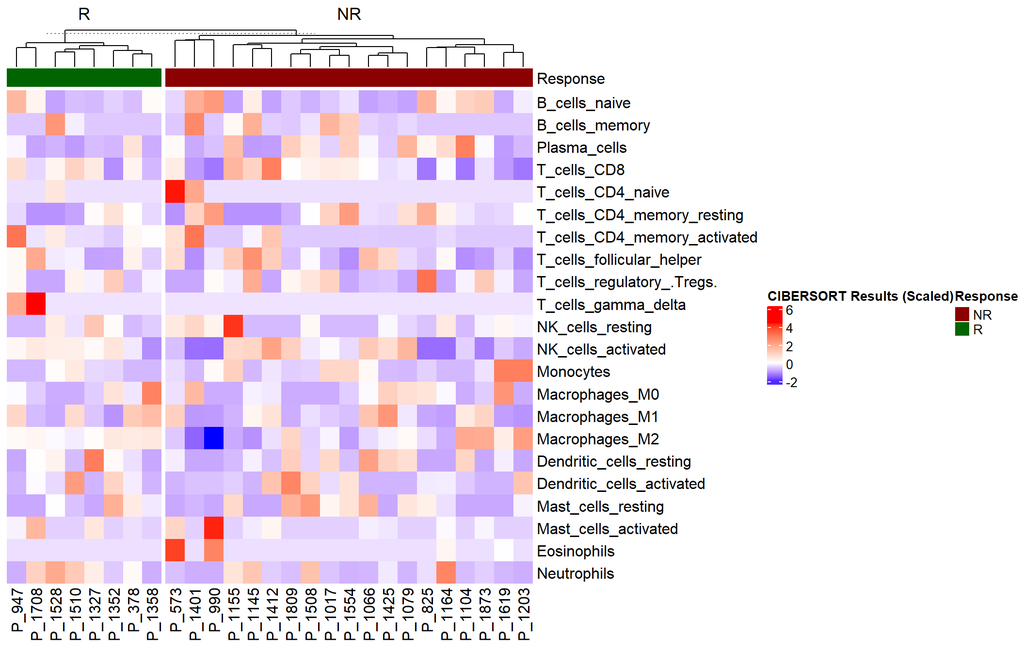

```r
# Save the CIBERSORT results as a CSV file
# write.csv(cibersort_results, file = file.path(Base_dir, "outputs/Deconvolution_outputs", "ICB_Jung__Lung__PD-(L)1_CIBERSORT_Deconvolution_Results.csv"), row.names = TRUE)

#TODO
# Correct column names for removal
# filtered_cibersort_results <- cibersort_results %>%
#   select(-`P-value`, -`Correlation`, -`RMSE`)
filtered_cibersort_results <- cibersort_results %>%
  select(-`P.value`, -`Correlation`, -`RMSE`)


filtered_cibersort_results <- scale(filtered_cibersort_results)

# Reorder data based on response
reorder_index <- order(clin_jung$response)
filtered_cibersort_results <- filtered_cibersort_results[reorder_index, ]
clin_jung <- clin_jung[reorder_index, ]

# Custom colors for response annotation (Responser vs Non-responder)
response_colors <- c("R" = "darkgreen", "NR" = "darkred")

# Create the custom annotation with color mapping
response_annotation <- HeatmapAnnotation(
  Response = clin_jung$response,
  col = list(Response = response_colors)  # Map colors to response categories
)

# Create a heatmap with the filtered results and custom response annotation
h <- Heatmap(t(as.matrix(filtered_cibersort_results)),
             name = "CIBERSORT Results (Scaled)",
             top_annotation = response_annotation,
             cluster_rows = F,
             column_split = clin_jung$response, col = colorRamp2(c(min(filtered_cibersort_results), 0, max(filtered_cibersort_results)), c("blue", "white", "red")))


h
```

The **CIBERSORT** deconvolution analysis of the **Jung Lung PD-1/PD-L1** dataset provides a comprehensive view of the tumor microenvironment (TME) by estimating the abundance of various immune and stromal cell types in patients receiving PD-1/PD-L1 therapy for lung cancer.

### EPIC Deconvolution on **Jung Lung PD-1/PD-L1**

In this section, we perform **EPIC** deconvolution analysis on the **Jung Lung PD-1/PD-L1** dataset to estimate the abundance of immune and stromal cell types within the tumor microenvironment (TME). The dataset contains RNA-seq expression data, and clinical data such as patient response (responder or non-responder) to treatment.

#### Steps Involved:

1. **Load the Data**: First, we load the specific dataset for **ICB_Jung_Lung_PD-(L)1** from the `data_all` directory, which contains gene expression and clinical data.
2. **Prepare Expression Data**: The gene expression data is extracted and normalized, typically using `log2(TPM + 1)` for compatibility with the EPIC method.
3. **Run EPIC**: The **EPIC** deconvolution method is applied to estimate the relative abundance of different immune and stromal cell types in the TME.
4. **Create Visualization**: Visualizations such as heatmaps are generated to show the distribution of immune and stromal cell types in responders (R) vs non-responders (NR).

#### Interpretation:

- **Immune and Stromal Cell Identification**: EPIC estimates the proportions of immune cells (e.g., T cells, macrophages) and stromal cells (e.g., fibroblasts) in the TME.
- **Response Patterns**: By comparing responders and non-responders, we can see which cell types may be linked to the therapeutic response. Higher levels of certain immune cells may correlate with a better treatment response.
- **Implications for Personalized Therapy**: Understanding TME composition through EPIC analysis helps identify immune and stromal cells that contribute to the response, providing insights for the development of personalized treatment strategies in cancer immunotherapy.

#### Key Features:

- **Cell Types**: Immune cells, stromal cells, and cancer cells.
- **Approach**: EPIC uses cell-type-specific gene expression signatures to estimate the proportions of immune and stromal cells in tumor samples.
- **Documentation**: [EPIC GitHub](https://github.com/GfellerLab/EPIC)

```r
# 30 patients threshold - limitaion of min samples
# Define Function For all Deconvolution all remaing methods
create_heatmaps <- function(data, name) {

  # Reorder data based on response
  reorder_index <- order(clin_jung$response)
  data <- data[reorder_index, ]
  clin_jung <- clin_jung[reorder_index, ]

  # Handle missing values: replace NAs with the median of each column
  #data[is.na(data)] <- apply(data, 2, median, na.rm = TRUE)

  # Scaled version
  data_scaled <- as.data.frame(scale(data))

  # Print the range of scaled data
  #cat("Range for", name, ":", range(data_scaled), "\n")

  # Custom colors for response annotation (Responser vs Non-responder)
  response_colors <- c("R" = "darkgreen", "NR" = "darkred")

  # Create the custom annotation with color mapping
  response_annotation <- HeatmapAnnotation(
    Response = clin_jung$response,
    col = list(Response = response_colors)  # Map colors to response categories
  )

  h_scaled <- Heatmap(t(as.matrix(data_scaled)), name = paste(name, "(Scaled)"),
                      top_annotation = response_annotation,
                      cluster_rows = FALSE, column_split = clin_jung$response,
                      col = colorRamp2(c(min(data_scaled), 0, max(data_scaled)), c("blue", "white", "red")))

  # Display scaled heatmap
  draw(h_scaled)

}

# Example usage for EPIC, MCPcounter, xCell, and ESTIMATE results

#2.EPIC
# Run deconvolution analysis and generate heatmap for EPIC
epic_results <- as.data.frame(deconvo_tme(eset = expr_Jung, method = "epic"))
rownames(epic_results) <- epic_results$ID
epic_results$ID <- NULL

# write.csv(epic_results, file = file.path(Base_dir, "outputs/Deconvolution_outputs/ICB_Jung__Lung__PD-(L)1/", "ICB_Jung_EPIC_Deconvolution_Results.csv"), row.names = TRUE)

kable(epic_results, format = "html", caption = "EPIC Deconvolution Results") %>%
  kable_styling(bootstrap_options = c("striped", "hover", "condensed", "responsive"), full_width = F) %>% scroll_box(height = "400px")
```

EPIC Deconvolution Results

|  | Bcells_EPIC | CAFs_EPIC | CD4_Tcells_EPIC | CD8_Tcells_EPIC | Endothelial_EPIC | Macrophages_EPIC | NKcells_EPIC | otherCells_EPIC |
| --- | --- | --- | --- | --- | --- | --- | --- | --- |
| P_990 | 0.0190993 | 0.0128929 | 0.1749160 | 0.0361121 | 0.0750611 | 0.0079058 | 0.0000000 | 0.6740128 |
| P_947 | 0.0402616 | 0.0173281 | 0.2353178 | 0.1212133 | 0.0906243 | 0.0142330 | 0.0000000 | 0.4810218 |
| P_825 | 0.0083021 | 0.0131266 | 0.1090356 | 0.0441126 | 0.1036717 | 0.0067376 | 0.0000000 | 0.7150139 |
| P_573 | 0.0324530 | 0.0159216 | 0.2788504 | 0.0714504 | 0.0973619 | 0.0126787 | 0.0005876 | 0.4906964 |
| P_378 | 0.0285454 | 0.0161055 | 0.1665431 | 0.0738539 | 0.1230394 | 0.0138947 | 0.0006664 | 0.5773516 |
| P_1873 | 0.0352778 | 0.0217848 | 0.1607629 | 0.0440122 | 0.1203461 | 0.0124407 | 0.0000000 | 0.6053754 |
| P_1809 | 0.0273945 | 0.0165068 | 0.1308452 | 0.0737390 | 0.0876973 | 0.0137282 | 0.0000000 | 0.6500889 |
| P_1708 | 0.0799072 | 0.0123048 | 0.2050006 | 0.1243666 | 0.0615981 | 0.0203004 | 0.0005125 | 0.4960099 |
| P_1619 | 0.0178963 | 0.0264897 | 0.1891956 | 0.0548904 | 0.1903717 | 0.0169559 | 0.0000000 | 0.5042005 |
| P_1554 | 0.0506664 | 0.0241913 | 0.1863261 | 0.0532195 | 0.1787257 | 0.0100130 | 0.0000000 | 0.4968579 |
| P_1528 | 0.0333917 | 0.0085894 | 0.1158878 | 0.1239982 | 0.0359673 | 0.0165764 | 0.0066078 | 0.6589815 |
| P_1510 | 0.0395162 | 0.0077597 | 0.1790613 | 0.0997360 | 0.0596247 | 0.0137906 | 0.0006487 | 0.5998627 |
| P_1508 | 0.0400078 | 0.0110195 | 0.1996347 | 0.0850862 | 0.1304522 | 0.0108563 | 0.0000000 | 0.5229433 |
| P_1425 | 0.0167531 | 0.0117224 | 0.1843411 | 0.0782863 | 0.1095589 | 0.0103024 | 0.0000000 | 0.5890358 |
| P_1412 | 0.0034597 | 0.0161822 | 0.1555764 | 0.0738234 | 0.0960068 | 0.0100158 | 0.0006512 | 0.6442847 |
| P_1401 | 0.0783740 | 0.0187359 | 0.3076424 | 0.0638645 | 0.1231002 | 0.0093380 | 0.0000000 | 0.3989450 |
| P_1358 | 0.0120666 | 0.0175615 | 0.1435252 | 0.0746484 | 0.0816450 | 0.0114150 | 0.0000000 | 0.6591382 |
| P_1352 | 0.0064281 | 0.0172166 | 0.1932348 | 0.0393333 | 0.1050085 | 0.0097725 | 0.0000000 | 0.6290061 |
| P_1327 | 0.0403165 | 0.0051051 | 0.1911297 | 0.0839016 | 0.0681622 | 0.0153279 | 0.0016617 | 0.5943952 |
| P_1203 | 0.0170412 | 0.0118605 | 0.1260303 | 0.0288906 | 0.0900098 | 0.0153764 | 0.0000001 | 0.7107912 |
| P_1164 | 0.0157457 | 0.0147735 | 0.1305719 | 0.0813252 | 0.1103034 | 0.0088224 | 0.0000000 | 0.6384579 |
| P_1155 | 0.0368781 | 0.0131759 | 0.1617050 | 0.0656773 | 0.1204035 | 0.0111327 | 0.0042946 | 0.5867329 |
| P_1145 | 0.0851685 | 0.0118076 | 0.1978096 | 0.1189804 | 0.0551899 | 0.0156460 | 0.0007309 | 0.5146673 |
| P_1104 | 0.0139333 | 0.0142416 | 0.1308388 | 0.0396937 | 0.1190295 | 0.0088602 | 0.0000000 | 0.6734029 |
| P_1079 | 0.0373546 | 0.0237511 | 0.2503751 | 0.0526378 | 0.0924757 | 0.0145860 | 0.0010816 | 0.5277381 |
| P_1066 | 0.0308038 | 0.0168454 | 0.1928615 | 0.0778310 | 0.1606391 | 0.0129258 | 0.0007532 | 0.5073401 |
| P_1017 | 0.0563795 | 0.0269201 | 0.1961024 | 0.0912744 | 0.1582876 | 0.0134908 | 0.0000000 | 0.4575451 |

[figure not shown]

```r
create_heatmaps(epic_results, "EPIC Results")
```

In above heatmap, we perform **EPIC** deconvolution on the **Jung Lung PD-1/PD-L1** dataset to estimate the relative abundance of immune and stromal cells in the tumor microenvironment (TME) of lung cancer patients treated with PD-1/PD-L1 therapy.

#### Key Observations:

Overall **EPIC** analysis provides insights into how immune and stromal cell types contribute to the TME and influence the response to PD-1/PD-L1 therapy. By identifying cell type distributions and differences between responders and non-responders, EPIC can inform personalized therapeutic strategies for improving cancer treatment outcomes.

### MCPcounter Deconvolution on **Jung Lung PD-1/PD-L1**

In this section, we perform **MCPcounter** deconvolution analysis on the **Jung Lung PD-1/PD-L1** dataset to estimate the relative abundance of immune and stromal cell types within the tumor microenvironment (TME) of lung cancer patients treated with PD-1/PD-L1 therapy. MCPcounter is a method designed to estimate the proportion of various cell types from gene expression data.

#### Key Features:

- **Cell Types**: Immune cells (e.g., T cells, B cells, macrophages) and stromal cells (e.g., fibroblasts, endothelial cells).
- **Approach**: **MCPcounter** uses a signature matrix of known gene expression profiles to estimate the relative abundance of immune and stromal cell types in tissue samples.
- **Documentation**: [MCPcounter GitHub](https://github.com/ebecht/MCPcounter)

#### Steps:

1. **Data Preparation**: We begin by loading the **Jung Lung PD-1/PD-L1** dataset containing gene expression data along with the clinical response information.
2. **Normalization**: Normalize the gene expression data, typically using log2(TPM + 1).
3. **Run MCPcounter**: Apply the **MCPcounter** deconvolution method to estimate the proportions of immune and stromal cells in the TME.
4. **Visualization**: Visualize the results using heatmaps or other plots to compare immune and stromal cell distributions between responders (R) and non-responders (NR).

#### Interpretation:

- **Immune and Stromal Cell Identification**: **MCPcounter** provides estimates for various immune cell types (e.g., T cells, B cells, macrophages) as well as stromal cells (e.g., fibroblasts, endothelial cells).
- **Response Patterns**: By comparing the proportions of immune and stromal cells between responders (R) and non-responders (NR), we can identify which cell types may be contributing to the therapeutic response. For instance, higher proportions of certain immune cell subsets could be associated with a better response to PD-1/PD-L1 therapy.
- **Implications for Personalized Therapy**: The insights from MCPcounter can help guide the development of personalized treatment strategies by identifying key cell types that play a crucial role in mediating responses to immunotherapy.

```r
#3.MCPcounter

# Run deconvolution analysis and generate heatmap for MCPcounter
mcpcounter_results <- as.data.frame(deconvo_tme(eset = expr_Jung, method = "mcpcounter"))
rownames(mcpcounter_results) <- colnames(expr_Jung)
mcpcounter_results$ID <- NULL
kable(mcpcounter_results, format = "html", caption = "MCPcounter Deconvolution Results") %>%
  kable_styling(bootstrap_options = c("striped", "hover", "condensed", "responsive"), full_width = F) %>%scroll_box(height = "400px")
```

MCPcounter Deconvolution Results

|  | T_cells_MCPcounter | CD8_T_cells_MCPcounter | Cytotoxic_lymphocytes_MCPcounter | B_lineage_MCPcounter | NK_cells_MCPcounter | Monocytic_lineage_MCPcounter | Myeloid_dendritic_cells_MCPcounter | Neutrophils_MCPcounter | Endothelial_cells_MCPcounter | Fibroblasts_MCPcounter |
| --- | --- | --- | --- | --- | --- | --- | --- | --- | --- | --- |
| P_990 | 0.9439158 | 0.0000000 | 0.3489856 | 0.4410215 | 0.2405267 | 2.764130 | 0.4603888 | 1.833089 | 1.6129673 | 5.535670 |
| P_947 | 2.7034602 | 2.4260904 | 2.8154875 | 1.6258400 | 1.2789809 | 5.106695 | 1.5195314 | 1.653444 | 1.5147659 | 4.770744 |
| P_825 | 0.7649938 | 0.7468346 | 0.2868666 | 0.7195236 | 0.0790520 | 1.527465 | 0.5636743 | 2.364644 | 2.7129236 | 4.608595 |
| P_573 | 2.6192554 | 1.0669087 | 2.2627592 | 1.8375074 | 0.4420485 | 4.029018 | 1.4593951 | 2.405905 | 2.1149041 | 5.485578 |
| P_378 | 2.0892261 | 1.9200232 | 2.0341252 | 1.5341854 | 0.4822957 | 4.925005 | 2.4736232 | 3.271712 | 2.6004020 | 6.147643 |
| P_1873 | 1.2467373 | 0.6560030 | 0.9798412 | 1.7034381 | 0.2233716 | 4.131160 | 1.2351657 | 2.910267 | 2.7746217 | 7.902512 |
| P_1809 | 1.4958883 | 1.6922706 | 1.1666508 | 1.2334133 | 0.1079761 | 4.354151 | 2.6689088 | 2.153752 | 1.9932280 | 6.121665 |
| P_1708 | 2.7171758 | 3.3195273 | 2.2183115 | 3.6179998 | 0.5196902 | 5.339434 | 1.9786493 | 3.289912 | 1.1683718 | 3.914981 |
| P_1619 | 1.0305858 | 0.9824509 | 1.2010232 | 0.6912477 | 0.2294564 | 5.455786 | 2.8628957 | 1.912279 | 3.5282001 | 8.277876 |
| P_1554 | 1.5326301 | 1.0733278 | 1.0450740 | 2.4155990 | 0.1596748 | 2.869616 | 1.5130580 | 2.136722 | 3.4542773 | 8.007158 |
| P_1528 | 1.8924871 | 2.8505626 | 2.9851127 | 1.0539795 | 0.4505067 | 3.338984 | 1.6845102 | 3.205332 | 0.5714160 | 3.277854 |
| P_1510 | 2.2888023 | 2.4598308 | 2.5730652 | 2.0841024 | 0.6850247 | 4.740530 | 1.6870483 | 3.858941 | 1.3006040 | 3.114996 |
| P_1508 | 2.3156448 | 1.9774898 | 2.4712099 | 1.8972755 | 0.5836834 | 3.493575 | 2.4929898 | 3.672615 | 2.7849150 | 5.221446 |
| P_1425 | 1.9206811 | 1.8456567 | 1.7795805 | 0.9404622 | 0.3959639 | 3.762639 | 2.1539612 | 3.143051 | 2.2762780 | 4.433842 |
| P_1412 | 1.1216504 | 1.8478988 | 1.7449660 | 0.6278307 | 0.4147120 | 3.280108 | 1.0504486 | 1.950437 | 2.0266379 | 6.043626 |
| P_1401 | 3.2641691 | 1.3460523 | 1.4415349 | 4.9903070 | 0.2049089 | 3.625747 | 2.8333026 | 2.338905 | 2.4625132 | 6.283002 |
| P_1358 | 1.5064584 | 1.4167919 | 1.1372402 | 0.7916189 | 0.1707865 | 4.363846 | 1.1488766 | 2.002363 | 1.6001775 | 6.243220 |
| P_1352 | 1.1461813 | 0.0636321 | 0.9121397 | 0.5906101 | 0.2558187 | 3.377503 | 0.7246558 | 1.912460 | 2.4623094 | 6.868699 |
| P_1327 | 2.1599867 | 2.0975814 | 2.3187287 | 1.4088758 | 0.5825256 | 4.328603 | 3.4913000 | 2.882470 | 1.1463027 | 3.379522 |
| P_1203 | 0.5738256 | 0.0323176 | 0.6646332 | 1.0439849 | 0.0828689 | 3.373814 | 0.8495498 | 1.974315 | 1.4071277 | 4.167271 |
| P_1164 | 1.1223203 | 2.5184567 | 1.0114397 | 0.7204497 | 0.1841747 | 2.564691 | 0.6800010 | 3.225685 | 2.4816338 | 5.899444 |
| P_1155 | 1.4581806 | 0.5892907 | 2.4593178 | 0.9181352 | 0.1911521 | 2.004375 | 0.7572516 | 2.506621 | 1.4360984 | 3.960269 |
| P_1145 | 3.1032275 | 2.9860538 | 2.3949524 | 4.3684243 | 0.5020887 | 4.291727 | 2.0269791 | 3.527189 | 0.9752236 | 3.901044 |
| P_1104 | 0.6988363 | 0.0333950 | 1.8136275 | 0.7074263 | 0.0681693 | 1.963624 | 0.8227392 | 2.258640 | 2.3457000 | 5.377992 |
| P_1079 | 1.2749587 | 0.5257263 | 0.9294978 | 1.0040594 | 0.1533389 | 2.206282 | 1.6216515 | 1.161715 | 1.2309830 | 6.002272 |
| P_1066 | 2.0588774 | 1.1452014 | 1.9429802 | 1.3633225 | 0.4466225 | 4.295046 | 2.8719420 | 2.094372 | 3.2359367 | 6.691676 |
| P_1017 | 2.1900870 | 2.0716729 | 1.7126962 | 2.9044597 | 0.4095908 | 3.949966 | 2.8033995 | 2.293115 | 3.3238470 | 8.713875 |

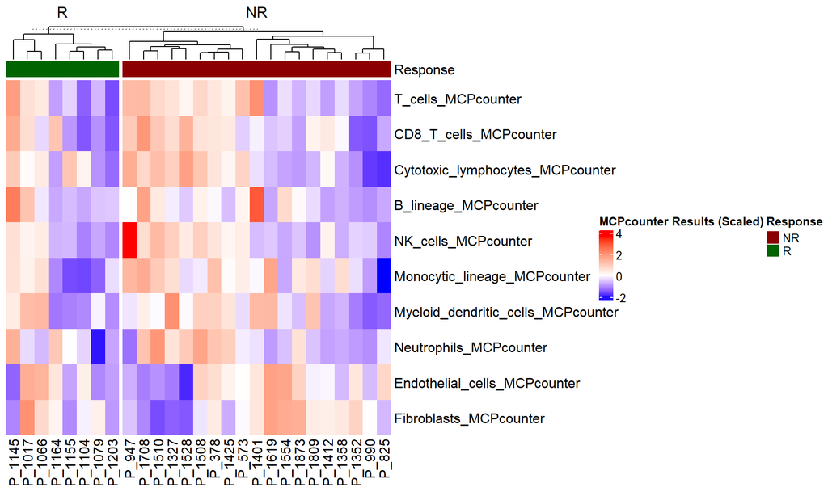

```r
 # write.csv(mcpcounter_results , file = file.path(Base_dir, "outputs/Deconvolution_outputs/ICB_Jung__Lung__PD-(L)1/", "ICB_Jung__Lung__PD-(L)1_MCPcounter_Deconvolution_Results.csv"), row.names = TRUE)

create_heatmaps(mcpcounter_results, "MCPcounter Results")
```

For **MCPcounter** deconvolution on the **Jung Lung PD-1/PD-L1** dataset, the analysis reveals the relative abundance of several immune and stromal cell types within the tumor microenvironment (TME). The heatmap generated provides insights into how these cell types vary between **responders (R)** and **non-responders (NR)**, focusing on:

Overall **MCPcounter** analysis provides a detailed view of how immune and stromal cell types are distributed in the TME and how their levels differ between responders and non-responders. These findings can help identify which cell types are associated with therapeutic efficacy and may provide potential biomarkers for predicting treatment outcomes and informing personalized therapies.

### xCell Deconvolution on **Jung Lung PD-1/PD-L1**

In this section, we perform **xCell** deconvolution analysis on the **Jung Lung PD-1/PD-L1** dataset to estimate the relative abundance of immune and stromal cell types within the tumor microenvironment (TME) based on gene expression data.

#### Key Features:

- **Cell Types**: Immune cells (e.g., T cells, macrophages, B cells, NK cells) and stromal cells (e.g., endothelial cells, fibroblasts).
- **Approach**: **xCell** uses gene expression data to provide a high-resolution, cell-type-specific estimate of immune and stromal cell proportions in tissue samples.
- **Documentation**: [xCell GitHub](https://github.com/Teichlab/xCell)

#### Steps Involved:

1. **Load the Data**: We load the **Jung Lung PD-1/PD-L1** dataset, which contains gene expression data and clinical response (responder or non-responder) information.
2. **Normalization**: The gene expression data is normalized to the format `log2(TPM + 1)` for consistency across samples.
3. **Run xCell**: The **xCell** deconvolution method is applied to estimate immune and stromal cell proportions in the TME.
4. **Visualization**: Results are visualized through a heatmap to compare the relative abundance of various immune and stromal cell types between responders (R) and non-responders (NR).

#### Interpretation:

- **Immune and Stromal Cell Identification**: **xCell** provides an estimate of immune cell types, including T cells, macrophages, NK cells, and B cells, as well as stromal cell types like fibroblasts and endothelial cells.
- **Response Patterns**: Differences between responders (R) and non-responders (NR) reveal which cell types might be associated with better therapeutic outcomes. For instance, higher proportions of CD8+ T cells or macrophages could correlate with improved response to PD-1/PD-L1 therapy.
- **Implications for Personalized Therapy**: By analyzing TME cell type distributions, **xCell** helps to identify the cellular components that contribute to treatment response, potentially informing personalized immunotherapy strategies.

```r
#4.xCell
# Run deconvolution analysis and generate heatmap for xCell
xcell_results <- as.data.frame(deconvo_tme(eset = expr_Jung, method = "xcell"))
```

[output not shown]

```r
rownames(xcell_results) <- colnames(expr_Jung)
xcell_results$ID <- NULL
kable(xcell_results, format = "html", caption = "xCell Deconvolution Results") %>%
  kable_styling(bootstrap_options = c("striped", "hover", "condensed", "responsive"), full_width = F) %>%scroll_box(height = "400px")
```

xCell Deconvolution Results

|  | aDC_xCell | Adipocytes_xCell | Astrocytes_xCell | B-cells_xCell | Basophils_xCell | CD4+_memory_T-cells_xCell | CD4+_naive_T-cells_xCell | CD4+_T-cells_xCell | CD4+_Tcm_xCell | CD4+_Tem_xCell | CD8+_naive_T-cells_xCell | CD8+_T-cells_xCell | CD8+_Tcm_xCell | CD8+_Tem_xCell | cDC_xCell | Chondrocytes_xCell | Class-switched_memory_B-cells_xCell | CLP_xCell | CMP_xCell | DC_xCell | Endothelial_cells_xCell | Eosinophils_xCell | Epithelial_cells_xCell | Erythrocytes_xCell | Fibroblasts_xCell | GMP_xCell | Hepatocytes_xCell | HSC_xCell | iDC_xCell | … |
| --- | --- | --- | --- | --- | --- | --- | --- | --- | --- | --- | --- | --- | --- | --- | --- | --- | --- | --- | --- | --- | --- | --- | --- | --- | --- | --- | --- | --- | --- | --- |
| P_990 | 0 | 0 | 0 | 0e+00 | 2.3e-06 | 0 | 0 | 0 | 0e+00 | 7.0e-07 | 0 | 0 | 0 | 0 | 0e+00 | 0 | 0e+00 | 0 | 0 | 0 | 0 | 0 | 0e+00 | 0 | 0 | 0 | 0 | 0 | 0 | … |
| P_947 | 0 | 0 | 0 | 1e-07 | 3.0e-06 | 0 | 0 | 0 | 2e-07 | 3.9e-06 | 0 | 0 | 0 | 0 | 0e+00 | 0 | 2e-07 | 0 | 0 | 0 | 0 | 0 | 0e+00 | 0 | 0 | 0 | 0 | 0 | 0 | … |
| P_825 | 0 | 0 | 0 | 0e+00 | 9.0e-07 | 0 | 0 | 0 | 0e+00 | 4.0e-07 | 0 | 0 | 0 | 0 | 0e+00 | 0 | 1e-07 | 0 | 0 | 0 | 0 | 0 | 0e+00 | 0 | 0 | 0 | 0 | 0 | 0 | … |
| P_573 | 0 | 0 | 0 | 0e+00 | 4.9e-06 | 0 | 0 | 0 | 2e-07 | 2.8e-06 | 0 | 0 | 0 | 0 | 0e+00 | 0 | 1e-07 | 0 | 0 | 0 | 0 | 0 | 0e+00 | 0 | 0 | 0 | 0 | 0 | 0 | … |
| P_378 | 0 | 0 | 0 | 0e+00 | 2.2e-06 | 0 | 0 | 0 | 0e+00 | 2.2e-06 | 0 | 0 | 0 | 0 | 0e+00 | 0 | 0e+00 | 0 | 0 | 0 | 0 | 0 | 0e+00 | 0 | 0 | 0 | 0 | 0 | 0 | … |
| P_1873 | 0 | 0 | 0 | 0e+00 | 6.0e-07 | 0 | 0 | 0 | 0e+00 | 7.0e-07 | 0 | 0 | 0 | 0 | 0e+00 | 0 | 0e+00 | 0 | 0 | 0 | 0 | 0 | 0e+00 | 0 | 0 | 0 | 0 | 0 | 0 | … |
| P_1809 | 0 | 0 | 0 | 0e+00 | 1.5e-06 | 0 | 0 | 0 | 0e+00 | 9.0e-07 | 0 | 0 | 0 | 0 | 0e+00 | 0 | 0e+00 | 0 | 0 | 0 | 0 | 0 | 0e+00 | 0 | 0 | 0 | 0 | 0 | 0 | … |
| P_1708 | 0 | 0 | 0 | 1e-07 | 5.3e-06 | 0 | 0 | 0 | 0e+00 | 3.6e-06 | 0 | 0 | 0 | 0 | 0e+00 | 0 | 3e-07 | 0 | 0 | 0 | 0 | 0 | 0e+00 | 0 | 0 | 0 | 0 | 0 | 0 | … |
| P_1619 | 0 | 0 | 0 | 0e+00 | 2.9e-06 | 0 | 0 | 0 | 0e+00 | 8.0e-07 | 0 | 0 | 0 | 0 | 0e+00 | 0 | 0e+00 | 0 | 0 | 0 | 0 | 0 | 0e+00 | 0 | 0 | 0 | 0 | 0 | 0 | … |
| P_1554 | 0 | 0 | 0 | 0e+00 | 5.0e-07 | 0 | 0 | 0 | 0e+00 | 1.3e-06 | 0 | 0 | 0 | 0 | 0e+00 | 0 | 0e+00 | 0 | 0 | 0 | 0 | 0 | 0e+00 | 0 | 0 | 0 | 0 | 0 | 0 | … |
| P_1528 | 0 | 0 | 0 | 0e+00 | 8.0e-06 | 0 | 0 | 0 | 0e+00 | 2.2e-06 | 0 | 0 | 0 | 0 | 0e+00 | 0 | 0e+00 | 0 | 0 | 0 | 0 | 0 | 0e+00 | 0 | 0 | 0 | 0 | 0 | 0 | … |
| P_1510 | 0 | 0 | 0 | 0e+00 | 5.8e-06 | 0 | 0 | 0 | 0e+00 | 4.5e-06 | 0 | 0 | 0 | 0 | 0e+00 | 0 | 0e+00 | 0 | 0 | 0 | 0 | 0 | 0e+00 | 0 | 0 | 0 | 0 | 0 | 0 | … |
| P_1508 | 0 | 0 | 0 | 0e+00 | 4.3e-06 | 0 | 0 | 0 | 5e-07 | 1.6e-06 | 0 | 0 | 0 | 0 | 0e+00 | 0 | 2e-07 | 0 | 0 | 0 | 0 | 0 | 0e+00 | 0 | 0 | 0 | 0 | 0 | 0 | … |
| P_1425 | 0 | 0 | 0 | 0e+00 | 3.3e-06 | 0 | 0 | 0 | 0e+00 | 3.0e-07 | 0 | 0 | 0 | 0 | 0e+00 | 0 | 0e+00 | 0 | 0 | 0 | 0 | 0 | 0e+00 | 0 | 0 | 0 | 0 | 0 | 0 | … |
| P_1412 | 0 | 0 | 0 | 0e+00 | 2.7e-06 | 0 | 0 | 0 | 0e+00 | 2.0e-07 | 0 | 0 | 0 | 0 | 0e+00 | 0 | 0e+00 | 0 | 0 | 0 | 0 | 0 | 0e+00 | 0 | 0 | 0 | 0 | 0 | 0 | … |
| P_1401 | 0 | 0 | 0 | 2e-07 | 1.4e-06 | 0 | 0 | 0 | 6e-07 | 4.0e-06 | 0 | 0 | 0 | 0 | 0e+00 | 0 | 4e-07 | 0 | 0 | 0 | 0 | 0 | 0e+00 | 0 | 0 | 0 | 0 | 0 | 0 | … |
| P_1358 | 0 | 0 | 0 | 0e+00 | 0.0e+00 | 0 | 0 | 0 | 0e+00 | 2.1e-06 | 0 | 0 | 0 | 0 | 0e+00 | 0 | 0e+00 | 0 | 0 | 0 | 0 | 0 | 0e+00 | 0 | 0 | 0 | 0 | 0 | 0 | … |
| P_1352 | 0 | 0 | 0 | 0e+00 | 0.0e+00 | 0 | 0 | 0 | 0e+00 | 4.0e-07 | 0 | 0 | 0 | 0 | 0e+00 | 0 | 0e+00 | 0 | 0 | 0 | 0 | 0 | 1e-07 | 0 | 0 | 0 | 0 | 0 | 0 | … |
| P_1327 | 0 | 0 | 0 | 0e+00 | 7.5e-06 | 0 | 0 | 0 | 0e+00 | 2.9e-06 | 0 | 0 | 0 | 0 | 0e+00 | 0 | 0e+00 | 0 | 0 | 0 | 0 | 0 | 0e+00 | 0 | 0 | 0 | 0 | 0 | 0 | … |
| P_1203 | 0 | 0 | 0 | 0e+00 | 2.5e-06 | 0 | 0 | 0 | 0e+00 | 8.0e-07 | 0 | 0 | 0 | 0 | 0e+00 | 0 | 0e+00 | 0 | 0 | 0 | 0 | 0 | 0e+00 | 0 | 0 | 0 | 0 | 0 | 0 | … |
| P_1164 | 0 | 0 | 0 | 0e+00 | 2.5e-06 | 0 | 0 | 0 | 0e+00 | 0.0e+00 | 0 | 0 | 0 | 0 | 0e+00 | 0 | 0e+00 | 0 | 0 | 0 | 0 | 0 | 0e+00 | 0 | 0 | 0 | 0 | 0 | 0 | … |
| P_1155 | 0 | 0 | 0 | 0e+00 | 6.7e-06 | 0 | 0 | 0 | 2e-07 | 9.0e-07 | 0 | 0 | 0 | 0 | 0e+00 | 0 | 0e+00 | 0 | 0 | 0 | 0 | 0 | 0e+00 | 0 | 0 | 0 | 0 | 0 | 0 | … |
| P_1145 | 0 | 0 | 0 | 1e-07 | 5.9e-06 | 0 | 0 | 0 | 4e-07 | 4.6e-06 | 0 | 0 | 0 | 0 | 0e+00 | 0 | 3e-07 | 0 | 0 | 0 | 0 | 0 | 0e+00 | 0 | 0 | 0 | 0 | 0 | 0 | … |
| P_1104 | 0 | 0 | 0 | 0e+00 | 0.0e+00 | 0 | 0 | 0 | 0e+00 | 0.0e+00 | 0 | 0 | 0 | 0 | 0e+00 | 0 | 0e+00 | 0 | 0 | 0 | 0 | 0 | 0e+00 | 0 | 0 | 0 | 0 | 0 | 0 | … |
| P_1079 | 0 | 0 | 0 | 0e+00 | 1.8e-06 | 0 | 0 | 0 | 9e-07 | 1.1e-06 | 0 | 0 | 0 | 0 | 0e+00 | 0 | 0e+00 | 0 | 0 | 0 | 0 | 0 | 0e+00 | 0 | 0 | 0 | 0 | 0 | 0 | … |
| P_1066 | 0 | 0 | 0 | 0e+00 | 3.0e-06 | 0 | 0 | 0 | 0e+00 | 2.9e-06 | 0 | 0 | 0 | 0 | 0e+00 | 0 | 0e+00 | 0 | 0 | 0 | 0 | 0 | 0e+00 | 0 | 0 | 0 | 0 | 0 | 0 | … |
| P_1017 | 0 | 0 | 0 | 2e-07 | 8.0e-07 | 0 | 0 | 0 | 8e-07 | 2.8e-06 | 0 | 0 | 0 | 0 | 1e-07 | 0 | 1e-07 | 0 | 0 | 0 | 0 | 0 | 0e+00 | 0 | 0 | 0 | 0 | 0 | 0 | … |

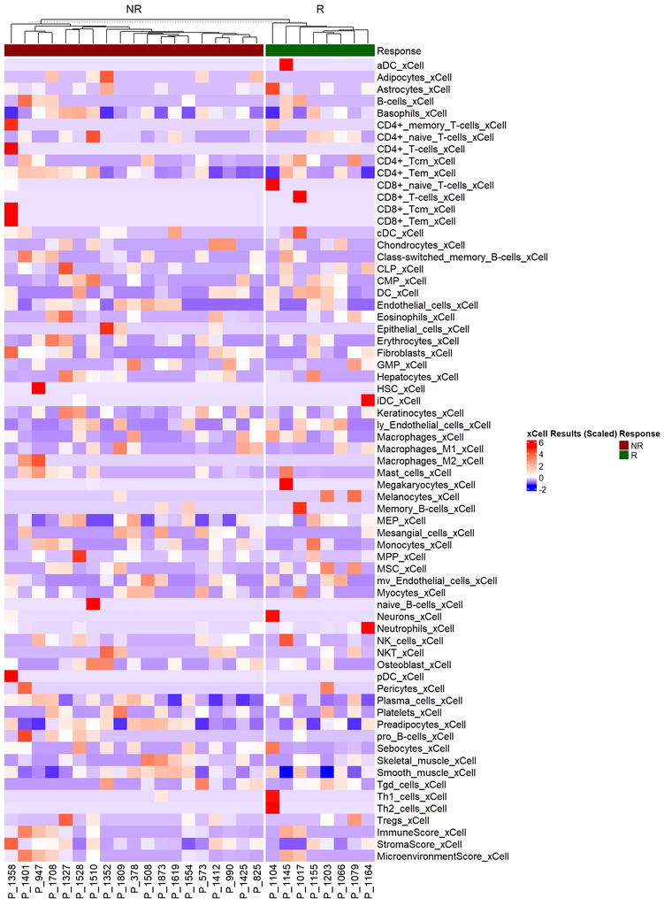

```r
 # write.csv(xcell_results , file = file.path(Base_dir, "outputs/Deconvolution_outputs/ICB_Jung__Lung__PD-(L)1/", "ICB_Jung__Lung__PD-(L)1_xCell_Deconvolution_Result"), row.names = TRUE)

create_heatmaps(xcell_results, "xCell Results")
```

#### Key Observations from the above Heatmap:

- **T Cells**: There are variations in **CD8+ T cells** and **CD4+ memory T cells** across patients. Responders (R) seem to show higher expression of CD8+ T cells in certain samples, which could indicate their role in the immune response to PD-1/PD-L1 therapy.
- **Macrophages**: Differences in the proportions of **Macrophages** (both M1 and M2 subtypes) are also notable, particularly with higher levels of macrophages in some responder patients, suggesting their involvement in promoting anti-tumor immunity.
- **Neutrophils and NK Cells**: The heatmap also shows variation in the abundance of **Neutrophils** and **NK cells**, with some groups exhibiting higher levels of these cells, potentially reflecting their contribution to the TME and therapeutic response.
- **Fibroblasts and Endothelial Cells**: **Fibroblasts** and **Endothelial cells** also exhibit differences across patients, indicating that stromal components may influence the treatment outcome, either by affecting immune cell recruitment or response.

#### Interpretation:

- **Response Patterns**: The **responders (R)** and **non-responders (NR)** exhibit distinct patterns of immune and stromal cell types. Higher proportions of certain immune cells like **CD8+ T cells**, **macrophages**, and **NK cells** could correlate with better treatment response.
- **Therapeutic Implications**: The findings suggest that certain immune and stromal cells might be critical in mediating the effects of PD-1/PD-L1 therapy. Identifying and targeting these cell types could enhance the personalization of cancer treatment strategies.

By examining the TME components in **Jung Lung PD-1/PD-L1** patients, **xCell** helps uncover potential biomarkers for treatment response and highlights cell populations that might be targeted to improve immunotherapy outcomes.

### Timer Deconvolution on **Jung Lung PD-1/PD-L1**

we perform **TIMER** deconvolution analysis on the **Jung Lung PD-1/PD-L1** dataset to estimate the relative abundance of immune cell types within the tumor microenvironment (TME) of patients treated with PD-1/PD-L1 therapy. **TIMER** is a powerful tool for characterizing immune infiltration based on gene expression data.

#### Key Features:

- **Cell Types**: Immune cells (e.g., CD8+ T cells, Tregs, macrophages, neutrophils, dendritic cells).
- **Approach**: **TIMER** utilizes a regression-based method to estimate the proportion of immune cells in bulk gene expression data by analyzing the expression of specific immune cell markers.
- **Documentation**: [TIMER GitHub](https://cistrome.shinyapps.io/timer/)

#### Steps :

1. **Data Preparation**: The **Jung Lung PD-1/PD-L1** dataset, containing RNA-seq gene expression data and clinical information on patient response, is loaded.
2. **Normalization**: The gene expression data is normalized to ensure consistency across samples.
3. **Run TIMER Deconvolution**: **TIMER** is used to estimate the immune cell proportions in each sample.
4. **Visualization**: The results are visualized in the form of a heatmap, comparing the immune cell compositions in responders (R) vs. non-responders (NR).

#### Interpretation:

By identifying immune cell distributions in the **Jung Lung PD-1/PD-L1** samples, **TIMER** helps to shed light on the key immune components that could be leveraged for improving immunotherapy outcomes. This analysis could guide more targeted treatments by identifying immune cell populations that influence the response to PD-1/PD-L1 therapy.

```r
# Timer method (1.)

timer_results <- deconvo_timer(expr_Jung, project = NULL, indications = rep("luad",dim(expr_Jung)[2]))
```

```
## [1] "Outlier genes: ACTB AKR1C2 B2M EEF1A1 FN1 FTH1 FTL HBA1 HBA2 HBB HP KRT17 MT-ATP6 MT-ATP8 MT-CO1 MT-CO2 MT-CO3 MT-ND2 MT-ND3 MT-ND4 MT-ND4L MT-ND6 NBPF9 RPL8 RPS17 RPS18 RPS6 S100A6 S100A8 S100A9 SCGB3A1 SFTPA2 TMSB10 TMSB4X UBC VIM XAGE1B"
```

```
## Found 29 genes with uniform expression within a single batch (all zeros); these will not be adjusted for batch.
```

```r
 # write.csv(timer_results , file = file.path(Base_dir, "outputs/Deconvolution_outputs/ICB_Jung__Lung__PD-(L)1/", "ICB_jung_TIMER_Deconvolution_Results.csv"), row.names = TRUE)

timer_results$ID <- NULL
kable(timer_results, format = "html", caption = "Timer Deconvolution Results") %>%
  kable_styling(bootstrap_options = c("striped", "hover", "condensed", "responsive"))
```

Timer Deconvolution Results

| B_cell_TIMER | T_cell_CD4_TIMER | T_cell_CD8_TIMER | Neutrophil_TIMER | Macrophage_TIMER | DC_TIMER |
| --- | --- | --- | --- | --- | --- |
| 0.0946593 | 0.1233359 | 0.1999457 | 0.1224507 | 0.0542809 | 0.4880901 |
| 0.0992085 | 0.1226277 | 0.2148523 | 0.1240275 | 0.0567777 | 0.4968424 |
| 0.0938410 | 0.1246007 | 0.1939317 | 0.1190288 | 0.0566356 | 0.4873731 |
| 0.0984900 | 0.1251095 | 0.2082436 | 0.1286441 | 0.0558915 | 0.4951366 |
| 0.0965799 | 0.1187980 | 0.2113410 | 0.1302029 | 0.0607068 | 0.4974625 |
| 0.0963584 | 0.1255226 | 0.1978163 | 0.1250059 | 0.0613996 | 0.4934183 |
| 0.0987315 | 0.1219834 | 0.2018403 | 0.1254025 | 0.0589835 | 0.4989938 |
| 0.1018306 | 0.1189423 | 0.2110641 | 0.1393446 | 0.0574223 | 0.5033194 |
| 0.0903332 | 0.1252154 | 0.2003881 | 0.1291559 | 0.0675191 | 0.5066289 |
| 0.0993355 | 0.1253316 | 0.2020188 | 0.1234743 | 0.0574813 | 0.4916611 |
| 0.0948821 | 0.1111572 | 0.2163043 | 0.1312342 | 0.0541741 | 0.4956793 |
| 0.0980927 | 0.1249565 | 0.2081681 | 0.1314701 | 0.0607716 | 0.4950418 |
| 0.0982987 | 0.1237358 | 0.2122309 | 0.1318732 | 0.0570954 | 0.4957722 |
| 0.0929919 | 0.1209229 | 0.2072727 | 0.1291710 | 0.0548447 | 0.4979543 |
| 0.0931015 | 0.1208534 | 0.2053593 | 0.1240485 | 0.0570796 | 0.4936403 |
| 0.1114547 | 0.1367976 | 0.2011398 | 0.1229690 | 0.0523439 | 0.4999233 |
| 0.0947152 | 0.1205804 | 0.2031795 | 0.1247593 | 0.0572742 | 0.4998594 |
| 0.0906270 | 0.1200219 | 0.2010632 | 0.1242695 | 0.0554190 | 0.4996704 |
| 0.0944913 | 0.1209237 | 0.2092243 | 0.1289966 | 0.0550019 | 0.5022177 |
| 0.0948923 | 0.1214913 | 0.1930753 | 0.1215940 | 0.0590111 | 0.4928279 |
| 0.0936335 | 0.1224583 | 0.2008544 | 0.1285981 | 0.0571775 | 0.4873345 |
| 0.0936266 | 0.1167857 | 0.2054823 | 0.1241217 | 0.0526093 | 0.4900414 |
| 0.1075344 | 0.1278434 | 0.2084989 | 0.1337751 | 0.0569001 | 0.4950084 |
| 0.0922741 | 0.1163697 | 0.2032399 | 0.1210955 | 0.0581474 | 0.4911111 |
| 0.0932458 | 0.1187500 | 0.2008555 | 0.1200528 | 0.0520236 | 0.4929733 |
| 0.0957446 | 0.1227621 | 0.2100144 | 0.1284778 | 0.0579788 | 0.4985276 |
| 0.1015574 | 0.1293136 | 0.2047626 | 0.1253315 | 0.0624986 | 0.4944835 |

```r
#TODO : patient id showsn n heatmap

#2. Timermethod (2.)
timer_results2 <- deconvo_tme(eset = expr_Jung, method =
              "timer", group_list = rep("luad", dim(expr_Jung)[2]))
```

```
## [1] "Outlier genes: ACTB AKR1C2 B2M EEF1A1 FN1 FTH1 FTL HBA1 HBA2 HBB HP KRT17 MT-ATP6 MT-ATP8 MT-CO1 MT-CO2 MT-CO3 MT-ND2 MT-ND3 MT-ND4 MT-ND4L MT-ND6 NBPF9 RPL8 RPS17 RPS18 RPS6 S100A6 S100A8 S100A9 SCGB3A1 SFTPA2 TMSB10 TMSB4X UBC VIM XAGE1B"
```

```
## Found 29 genes with uniform expression within a single batch (all zeros); these will not be adjusted for batch.
```

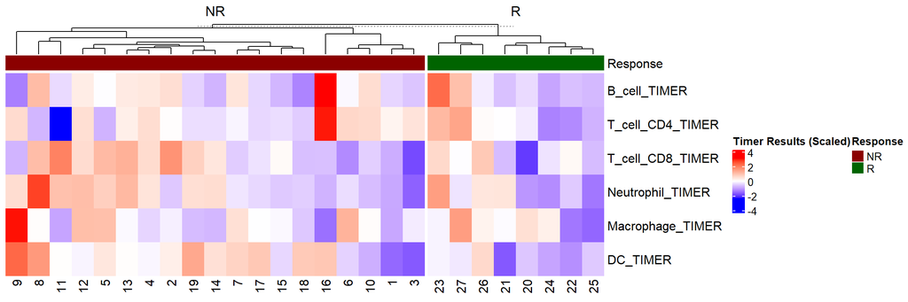

```r
create_heatmaps(timer_results, "Timer Results")
```

The **TIMER** deconvolution analysis on the **Jung Lung PD-1/PD-L1** dataset reveals immune cell distributions in the tumor microenvironment (TME) of patients receiving PD-1/PD-L1 therapy.

So **TIMER** analysis highlights immune cell differences in the TME, with potential implications for improving PD-1/PD-L1 therapy outcomes by targeting specific immune populations.

### Cell Signature Associations with Immunotherapy Outcomes (OS, PFS and Response (R vs NR))

After conducting the deconvolution analysis and identifying the tumor microenvironment (TME) cell signatures, we will now examine the associations between these cell signatures and immune-oncology (IO) outcomes, including **Progression-Free Survival (PFS)**, **Overall Survival (OS)**, and **Response** (R vs NR). This analysis will help us determine which cell types and their associated signatures are linked to treatment outcomes.

To achieve this, we will use the **PredictIO** package developed by the BHK Lab, which is designed to assess the relationship between cell signatures and clinical outcomes.

Here’s how you can perform this analysis. We start with PFS since this dataset doesn’t have OS:

```r
# Gene Association with Cell Signatures using the PredictIO Package

# Install and load PredictioR package
# devtools::install_github("bhklab/PredictioR")

# Load dataset (ICB Jung Lung PD-L1)
ICB_jung <- get(load(file.path(Base_dir, "data_all", "ICB_Jung__Lung__PD-(L)1.rda")))

# Set study parameters
geneSig.score <- cibersort_results
study_id <- "ICB_jung" #ICB_Jung__Lung__PD-(L)1
cancer_type <- "Lung"
treatment <- "PD-1/PD-L1"

# Run PFS association analysis for each CIBERSORT cell signature
cibersort_signatures <- cibersort_results[, 1:22] # remove columns "P-value", "Correlation" and "RSMSE"

res.all <- lapply(1:ncol(cibersort_signatures), function(k) {
    sig_name <- colnames(cibersort_signatures)[k]
    cellSig_vector <- as.numeric(cibersort_signatures[, k])  # Extract column as numeric vector

    # Perform survival analysis using geneSigSurvCont
    res <- tryCatch({
        geneSigSurvCont(
            dat.icb = ICB_jung,
            geneSig = cellSig_vector,
            time.censor = 24,       # Use 24 months for PFS (os is 36)
            n.cutoff = 25,          # Minimum sample size
            study = study_id,       # Study identifier
            surv.outcome = "PFS",   # PFS outcome
            sig.name = sig_name,    # Signature name
            cancer.type = cancer_type,
            treatment = treatment
        )
    }, error = function(e) {
        # Handle errors gracefully
        message(sprintf("Error in survival analysis for %s: %s", sig_name, e$message))
        return(data.frame(sig_name = sig_name, Pval = NA, FDR = NA))
    })

    return(res)
})

# Combine results, adjust p-values, and order by FDR
res.all <- do.call(rbind, res.all)
res.all$FDR <- p.adjust(res.all$Pval, method = "BH")
res.all <- res.all[order(res.all$FDR), ]


# Save results as a CSV file
# write.csv(res.all, file = file.path(Base_dir, "outputs/Deconvolution_outputs/ICB_Jung__Lung__PD-(L)1/", paste0(study_id,"_PFS_CIBERSORT_CellSig_Association.csv")), row.names = TRUE)

# Display results in HTML format
kable(res.all, format = "html", caption = "Association of CIBERSORT Cell Signatures with PFS in ICB Jung Dataset") %>%
  kable_styling(bootstrap_options = c("striped", "hover", "condensed", "responsive"), full_width = F) %>%
  scroll_box(height = "400px")
```

Association of CIBERSORT Cell Signatures with PFS in ICB Jung Dataset

|  | Outcome | Gene | Study | Coef | SE | N | Pval | Cancer_type | Treatment | FDR |
| --- | --- | --- | --- | --- | --- | --- | --- | --- | --- | --- |
| HR | PFS | B_cells_naive | ICB_jung | 2.839 | 4.697 | 27 | 0.5455415 | Lung | PD-1/PD-L1 | 0.9498669 |
| HR1 | PFS | B_cells_memory | ICB_jung | 1.129 | 5.549 | 27 | 0.8387881 | Lung | PD-1/PD-L1 | 0.9498669 |
| HR2 | PFS | Plasma_cells | ICB_jung | 9.805 | 6.394 | 27 | 0.1251737 | Lung | PD-1/PD-L1 | 0.9498669 |
| HR3 | PFS | T_cells_CD8 | ICB_jung | -1.662 | 5.403 | 27 | 0.7583330 | Lung | PD-1/PD-L1 | 0.9498669 |
| HR4 | PFS | T_cells_CD4_naive | ICB_jung | 3.950 | 6.859 | 27 | 0.5646684 | Lung | PD-1/PD-L1 | 0.9498669 |
| HR5 | PFS | T_cells_CD4_memory_resting | ICB_jung | 1.677 | 2.369 | 27 | 0.4791005 | Lung | PD-1/PD-L1 | 0.9498669 |
| HR6 | PFS | T_cells_CD4_memory_activated | ICB_jung | -8.343 | 10.858 | 27 | 0.4422627 | Lung | PD-1/PD-L1 | 0.9498669 |
| HR7 | PFS | T_cells_follicular_helper | ICB_jung | 3.608 | 8.904 | 27 | 0.6852972 | Lung | PD-1/PD-L1 | 0.9498669 |
| HR8 | PFS | T_cells_regulatory_.Tregs. | ICB_jung | -2.420 | 12.874 | 27 | 0.8509042 | Lung | PD-1/PD-L1 | 0.9498669 |
| HR9 | PFS | T_cells_gamma_delta | ICB_jung | -34.699 | 45.606 | 27 | 0.4467601 | Lung | PD-1/PD-L1 | 0.9498669 |
| HR10 | PFS | NK_cells_resting | ICB_jung | 4.654 | 11.239 | 27 | 0.6788152 | Lung | PD-1/PD-L1 | 0.9498669 |
| HR11 | PFS | NK_cells_activated | ICB_jung | -7.276 | 9.757 | 27 | 0.4558570 | Lung | PD-1/PD-L1 | 0.9498669 |
| HR12 | PFS | Monocytes | ICB_jung | 4.171 | 3.753 | 27 | 0.2664744 | Lung | PD-1/PD-L1 | 0.9498669 |
| HR13 | PFS | Macrophages_M0 | ICB_jung | -0.322 | 2.326 | 27 | 0.8897991 | Lung | PD-1/PD-L1 | 0.9498669 |
| HR14 | PFS | Macrophages_M1 | ICB_jung | -2.351 | 4.558 | 27 | 0.6059420 | Lung | PD-1/PD-L1 | 0.9498669 |
| HR15 | PFS | Macrophages_M2 | ICB_jung | -0.577 | 2.384 | 27 | 0.8089048 | Lung | PD-1/PD-L1 | 0.9498669 |
| HR16 | PFS | Dendritic_cells_resting | ICB_jung | -3.445 | 6.849 | 27 | 0.6149526 | Lung | PD-1/PD-L1 | 0.9498669 |
| HR18 | PFS | Mast_cells_resting | ICB_jung | 1.582 | 7.558 | 27 | 0.8342009 | Lung | PD-1/PD-L1 | 0.9498669 |
| HR19 | PFS | Mast_cells_activated | ICB_jung | -0.301 | 2.566 | 27 | 0.9066911 | Lung | PD-1/PD-L1 | 0.9498669 |
| HR20 | PFS | Eosinophils | ICB_jung | 8.727 | 20.989 | 27 | 0.6775528 | Lung | PD-1/PD-L1 | 0.9498669 |
| HR21 | PFS | Neutrophils | ICB_jung | -2.968 | 2.938 | 27 | 0.3124377 | Lung | PD-1/PD-L1 | 0.9498669 |
| HR17 | PFS | Dendritic_cells_activated | ICB_jung | -0.320 | 5.590 | 27 | 0.9542983 | Lung | PD-1/PD-L1 | 0.9542983 |

#### Cell Signature Associations with Immunotherapy Response (R vs NR)

- Goal: Perform logistic regression analysis to associate cell signatures with immunotherapy response (Responder vs Non-Responder) in the ICB Jung dataset.

```r
# Perform logistic regression for each cell signature in CIBERSORT
res.logreg <- lapply(1:ncol(cibersort_signatures), function(k) {
    sig_name <- colnames(cibersort_signatures)[k]
    cellSig_vector <- as.numeric(cibersort_signatures[, k])

    # Run the logistic regression with adjusted cutoffs
    res <- geneSigLogReg(
        dat.icb = ICB_jung,
        geneSig = cellSig_vector,
        n.cutoff = 2, #TODO: 30
        study = study_id,
        sig.name = sig_name,
        n0.cutoff = 5,   # Minimum responders  # TODO: check with with 5 ( check if we got error whcih study)
        n1.cutoff = 5,   # Minimum non-responders
        cancer.type = cancer_type,
        treatment = treatment
    )

    return(res)
})

# Combine all results into a single data frame
res.logreg <- do.call(rbind, res.logreg)

# Adjust p-values and order results by FDR
res.logreg$FDR <- p.adjust(res.logreg$Pval, method = "BH")
res.logreg <- res.logreg[order(res.logreg$FDR), ]

# Save results as a CSV file
# write.csv(res.logreg, file = file.path(Base_dir, "outputs/Deconvolution_outputs/ICB_Jung__Lung__PD-(L)1", paste0(study_id, "_Response_CIBERSORT_CellSig_Association.csv")), row.names = TRUE)

# Display results in HTML format
kable(res.logreg, format = "html", caption = "Association of CIBERSORT Cell Signatures with Response (R vs NR) in ICB Jung Dataset") %>%
  kable_styling(bootstrap_options = c("striped", "hover", "condensed", "responsive"), full_width = F) %>%
  scroll_box(height = "400px")
```

Association of CIBERSORT Cell Signatures with Response (R vs NR) in ICB Jung Dataset

|  | Outcome | Gene | Study | Coef | SE | N | Pval | Cancer_type | Treatment | FDR |
| --- | --- | --- | --- | --- | --- | --- | --- | --- | --- | --- |
| 1 | R vs NR | B_cells_naive | ICB_jung | 5.275 | 10.300 | 27 | 0.6085159 | Lung | PD-1/PD-L1 | 0.9822910 |
| 2 | R vs NR | B_cells_memory | ICB_jung | 4.320 | 11.608 | 27 | 0.7097601 | Lung | PD-1/PD-L1 | 0.9822910 |
| 3 | R vs NR | Plasma_cells | ICB_jung | 33.605 | 21.031 | 27 | 0.1100785 | Lung | PD-1/PD-L1 | 0.9822910 |
| 4 | R vs NR | T_cells_CD8 | ICB_jung | -2.298 | 8.031 | 27 | 0.7747886 | Lung | PD-1/PD-L1 | 0.9822910 |
| 5 | R vs NR | T_cells_CD4_naive | ICB_jung | 13.275 | 22.881 | 27 | 0.5618117 | Lung | PD-1/PD-L1 | 0.9822910 |
| 6 | R vs NR | T_cells_CD4_memory_resting | ICB_jung | 7.079 | 5.909 | 27 | 0.2309681 | Lung | PD-1/PD-L1 | 0.9822910 |
| 7 | R vs NR | T_cells_CD4_memory_activated | ICB_jung | -14.213 | 14.637 | 27 | 0.3315231 | Lung | PD-1/PD-L1 | 0.9822910 |
| 9 | R vs NR | T_cells_regulatory_.Tregs. | ICB_jung | 8.641 | 23.090 | 27 | 0.7082464 | Lung | PD-1/PD-L1 | 0.9822910 |
| 11 | R vs NR | NK_cells_resting | ICB_jung | 7.951 | 21.216 | 27 | 0.7078485 | Lung | PD-1/PD-L1 | 0.9822910 |
| 12 | R vs NR | NK_cells_activated | ICB_jung | -6.106 | 15.807 | 27 | 0.6992690 | Lung | PD-1/PD-L1 | 0.9822910 |
| 13 | R vs NR | Monocytes | ICB_jung | 15.617 | 13.880 | 27 | 0.2605494 | Lung | PD-1/PD-L1 | 0.9822910 |
| 14 | R vs NR | Macrophages_M0 | ICB_jung | -1.320 | 4.764 | 27 | 0.7817383 | Lung | PD-1/PD-L1 | 0.9822910 |
| 15 | R vs NR | Macrophages_M1 | ICB_jung | -5.335 | 8.260 | 27 | 0.5183751 | Lung | PD-1/PD-L1 | 0.9822910 |
| 16 | R vs NR | Macrophages_M2 | ICB_jung | -2.761 | 3.727 | 27 | 0.4587958 | Lung | PD-1/PD-L1 | 0.9822910 |
| 17 | R vs NR | Dendritic_cells_resting | ICB_jung | -3.768 | 11.469 | 27 | 0.7424728 | Lung | PD-1/PD-L1 | 0.9822910 |
| 18 | R vs NR | Dendritic_cells_activated | ICB_jung | -2.608 | 10.490 | 27 | 0.8036927 | Lung | PD-1/PD-L1 | 0.9822910 |
| 19 | R vs NR | Mast_cells_resting | ICB_jung | 6.370 | 15.179 | 27 | 0.6747080 | Lung | PD-1/PD-L1 | 0.9822910 |
| 22 | R vs NR | Neutrophils | ICB_jung | -5.455 | 4.710 | 27 | 0.2467473 | Lung | PD-1/PD-L1 | 0.9822910 |
| 8 | R vs NR | T_cells_follicular_helper | ICB_jung | 0.825 | 16.551 | 27 | 0.9602460 | Lung | PD-1/PD-L1 | 0.9956242 |
| 10 | R vs NR | T_cells_gamma_delta | ICB_jung | -1423.212 | 232386.725 | 27 | 0.9951135 | Lung | PD-1/PD-L1 | 0.9956242 |
| 20 | R vs NR | Mast_cells_activated | ICB_jung | -0.139 | 5.372 | 27 | 0.9793533 | Lung | PD-1/PD-L1 | 0.9956242 |
| 21 | R vs NR | Eosinophils | ICB_jung | 6104.190 | 1113042.651 | 27 | 0.9956242 | Lung | PD-1/PD-L1 | 0.9956242 |

## CIBERSORT Deconvolution on Immunotherapy Datasets

We applied the CIBERSORT deconvolution method across all immunotherapy datasets. Currently, 40 datasets are ready for analysis after applying exclusion criteria. Details of data processing can be found in the [Data Processing R Markdown file](https://github.com/sogolsahebi/EcoTyper_Project/blob/main/Scripts/Data_processing.html).

```r
process_ICB_dataset <- function(dataset_name) {
  tryCatch({

    #add
    dataset_name <- "ICB_Snyder__Ureteral__PD-(L)1"

    # Load the .rda file and assign it to a variable based on the dataset name
    dataset_path <- file.path(Base_dir, "data_all", paste0(dataset_name, ".rda"))
    loaded_data <- get(load(dataset_path))
    assign(dataset_name, loaded_data, envir = .GlobalEnv)

    # Extract expression data and convert back to TPM
    expr_data <- loaded_data@assays@data@listData[["gene_expression"]]
    expr_data <- as.matrix(expr_data)
    expr_TPM <- 2^(expr_data) - 0.001
    expr_data <- log2(expr_TPM + 1)

    #for "ICB_Prat__Lung__PD-(L)1" and "ICB_Prat__Melanoma__PD-(L)1"
    if (any(is.na(expr_data))){
    expr_data <- expr_data[complete.cases(expr_data), ]
    }

    # Run deconvolution analysis using CIBERSORT
    cibersort_results <- deconvo_tme(eset = expr_data, method = "cibersort")
    cibersort_results <- as.data.frame(cibersort_results)
    rownames(cibersort_results) <- colnames(expr_data)
    cibersort_results$ID <- NULL
    colnames(cibersort_results) <- gsub("_CIBERSORT", "", colnames(cibersort_results))

    # Save CIBERSORT results to CSV
    output_dir <- file.path(Base_dir, "outputs", "Deconvolution_outputs", dataset_name)
    dir.create(output_dir, recursive = TRUE, showWarnings = FALSE)
    csv_file_path <- file.path(output_dir, paste0(dataset_name, "_CIBERSORT_Deconvolution_Results.csv"))
    write.csv(cibersort_results, file = csv_file_path, row.names = TRUE)

    # Filter out irrelevant columns and scale data
    filtered_results <- cibersort_results %>%
      select(-`P-value`, -`Correlation`, -`RMSE`) %>%
      scale()

    # Extract and reorder clinical data based on response
    clin_data <- data.frame(colData(loaded_data))

   # Clean and standardize the response column
    clin_data$response <- ifelse(
      clin_data$response %in% c("R", "NR"),  # Keep "R" and "NR" as is
      clin_data$response,
      ifelse(is.na(clin_data$response), "Unknown", "Other")  # Replace NA with "Unknown" and others with "Other"
    )

    # Create custom color mapping for responses, including "Unknown"
    response_colors <- c("R" = "darkgreen", "NR" = "darkred", "Unknown" = "gray", "Other" = "orange")

    # Create heatmap annotations for responses
    response_annotation <- HeatmapAnnotation(
      Response = clin_data$response,
      col = list(Response = response_colors)
    )

    # Reorder data based on response for visualization
    reorder_index <- order(clin_data$response)  # Order by response
    filtered_results <- filtered_results[reorder_index, , drop = FALSE]
    clin_data <- clin_data[reorder_index, , drop = FALSE]

    # TODO: add remove Na and 0 columns(for prat)
    # filtered_results <- data.frame(filtered_results)
    # filtered_results$Dendritic_cells_activated <-NULL
    # Remove columns with all NA values
    #filtered_results <- filtered_results[, colSums(is.na(filtered_results)) < nrow(filtered_results)]

    h <- Heatmap(
      t(as.matrix(filtered_results)),  # Transpose to match heatmap format
      name = paste("CIBERSORT Results for", dataset_name, "(Scaled)"),
      top_annotation = response_annotation,  # Add annotations
      cluster_rows = FALSE,  # No clustering for rows
      column_split = clin_data$response,  # Split by response categories
      col = colorRamp2(c(min(filtered_results), 0, max(filtered_results)), c("blue", "white", "red"))
    )
    h

    # Save the heatmap as a PNG
    # output_dir <- file.path(Base_dir, "outputs", "Deconvolution_outputs", dataset_name)
    # dir.create(output_dir, recursive = TRUE, showWarnings = FALSE)
    # draw(h)
    # dev.off()
    #
    # Return the result file path for reference
    return(csv_file_path)
  }, error = function(e) {
    # Log any dataset that encounters an error
    message("Error processing dataset: ", dataset_name, " - ", e$message)
    return(NULL)  # Return NULL to continue to the next dataset
  })
}


# List of unique datasets
# IO_dataset <- unique(combined_clin$study)
# IO_dataset <- IO_dataset[21:28]  # Adjust indices as necessary

# # Error tracking list
# error_datasets <- list()
#
# # Example usage: Apply the process_ICB_dataset function to each dataset in IO_dataset
# results_paths <- lapply(IO_dataset, function(dataset_name) {
#   result <- process_ICB_dataset(dataset_name)
#   if (is.null(result)) error_datasets <<- c(error_datasets, dataset_name)  # Track datasets with errors
#   return(result)
# })
#
# # Display datasets with errors, if any
# if (length(error_datasets) > 0) {
#   print("The following datasets encountered errors and were skipped:")
#   print(error_datasets)
# } else {
#   print("All datasets processed successfully.")
# }
##########################################################

# Define the base directory
base_dir <- "~/OneDrive/Documents/BHK lab/EcoTyper_Project/outputs/Deconvolution_outputs"

# Get all CSV files recursively from subdirectories
csv_files <- list.files(base_dir, pattern = "\\.csv$", full.names = TRUE, recursive = TRUE)

# Function to preview CSV files
preview_csv_files <- function(file_paths) {
  lapply(file_paths, function(file) {
    tryCatch({
      data <- read.csv(file)
      head(data)  # Display the first few rows
    }, error = function(e) {
      paste("Error reading file:", file, "-", e$message)
    })
  })
}

# Preview all CSV files
previews <- preview_csv_files(csv_files)

# Display file names with their previews
names(previews) <- basename(csv_files)

# Print previews for user inspection
for (file_name in names(previews)) {
  cat("Preview of", file_name, ":\n")
  print(previews[[file_name]])
  cat("\n-----------------------------\n")
}

########################################

#TODOOO:

# Errors:
# 1. Error processing dataset: ICB_Jerby_Arnon__Melanoma__PD-(L)1 - There are only 1 signature genes matching common genes between bulk and reference profiles, but there should be more signature genes than reference cells


# 4. Running CIBERSORT
# Error processing dataset: ICB_Snyder__Ureteral__PD-(L)1 - assignment of an object of class “logical” is not valid for @‘colors’ in an object of class “ColorMapping”; is(value, "character") is not TRUE


# 5. Running CIBERSORT
# Error processing dataset: ICB_VanDenEnde__Esophageal__PD-(L)1 - assignment of an object of class “logical” is not valid for @‘colors’ in an object of class “ColorMapping”; is(value, "character") is not TRUE
```

```r
# Define directories
Base_dir <- "~/BHK lab/EcoTyper_Project/"
deconv_dir <- file.path(Base_dir, "outputs/Deconvolution_outputs/")

# Initialize lists to store results and errors
results <- list()  # To store actual results (data frames, etc.)
error_datasets <- list()  # To track datasets with errors

# Define the processing function
process_ICB_dataset <- function(dataset_name) {
  tryCatch({
    # Load the .rda file for the dataset
    rda_file <- file.path(Base_dir, "data_all", paste0(dataset_name, ".rda"))

    if (!file.exists(rda_file)) {
      stop("RDA file not found for dataset: ", dataset_name)
    }

    # Load the RDA file into the environment
    dataset_obj <- get(load(rda_file))

    # Validate the loaded dataset
    if (is.null(dataset_obj)) {
      stop("Failed to load RDA data for dataset: ", dataset_name)
    }

    # Locate the EPIC results file
    epic_file <- file.path(deconv_dir, dataset_name, paste0(dataset_name, "_EPIC_Deconvolution_Results.csv"))

    if (!file.exists(epic_file)) {
      stop("EPIC file not found for dataset: ", dataset_name)
    }

    # Load the EPIC results
    epic_results <- read.csv(epic_file, row.names = 1)

    # Validate EPIC results
    if (is.null(epic_results) || nrow(epic_results) == 0) {
      warning("Skipping dataset due to empty EPIC results: ", dataset_name)
      return(NULL)
    }

    # Perform logistic regression for each cell signature in EPIC results
    res.logreg <- lapply(1:nrow(epic_results), function(k) {
      sig_name <- rownames(epic_results)[k]
      cellSig_vector <- as.numeric(epic_results[k, ])

      # Run the logistic regression
      res <- geneSigLogReg(
        dat.icb = dataset_obj,  # Use the loaded dataset from .rda
        geneSig = cellSig_vector,
        n.cutoff = 30,
        study = dataset_name,
        sig.name = sig_name,
        n0.cutoff = 3,
        n1.cutoff = 5,
        cancer.type = cancer_type,
        treatment = treatment
      )
      return(res)
    })

    # Combine logistic regression results for the current dataset
    res.logreg <- do.call(rbind, res.logreg)

    # Adjust p-values and order results by FDR
    res.logreg$FDR <- p.adjust(res.logreg$Pval, method = "BH")
    res.logreg <- res.logreg[order(res.logreg$FDR), ]

    message("Processed results for dataset: ", dataset_name)
    return(res.logreg)  # Return the actual results (data frame)

  }, error = function(e) {
    # Log errors and return NULL
    message("Error processing dataset: ", dataset_name, " - ", e$message)
    return(NULL)
  })
}

# # Apply the processing function to each dataset in IO_dataset
# results <- lapply(IO_dataset, function(dataset_name) {
#   result <- process_ICB_dataset(dataset_name)
#   if (is.null(result)) error_datasets <<- c(error_datasets, dataset_name)  # Track datasets with errors
#   return(result)
# })

# # Remove NULL entries (datasets with errors) from the results list
# results <- results[!sapply(results, is.null)]
#
# # Display summary of successful results
# if (length(results) > 0) {
#   message("Successfully processed results for the following datasets:")
#   print(names(results))
# } else {
#   message("No datasets were successfully processed.")
# }

# Display summary of errors
if (length(error_datasets) > 0) {
  message("The following datasets encountered errors:")
  print(error_datasets)
}

# Save each dataset's results to CSV
output_dir <- file.path(deconv_dir, "Processed_Results")
dir.create(output_dir, showWarnings = FALSE)

for (i in seq_along(results)) {
  dataset_name <- names(results)[i]
  result <- results[[i]]
  write.csv(result, file = file.path(output_dir, paste0(dataset_name, "_Processed_LogReg_Results.csv")), row.names = TRUE)
}

message("All successful results saved to: ", output_dir)


#-----------------------------------------------------------------------------------------
# TODO:
# 3. For each dataset, generate the CIBERSORT list of cell signatures (in progress).
# 4. Associate cell types with IO response (focus on OS or PFS).
# 5. Next step: Based on step 4, integrate associations across pan-cancer, cancer-specific, and treatment-specific analyses.
```